# Homework 1

Christoph Sieker, Aman Sharma, Kasia Gasiewska, Satyam Gorry, Peter Moravec, Philippe Schrage

27.09.2020

```r
knitr::opts_chunk$set(
  message = FALSE,
  warning = FALSE,
  tidy=FALSE,     # display code as typed
  size="small")   # slightly smaller font for code
options(digits = 3)

# default figure size
knitr::opts_chunk$set(
  fig.width=6.75,
  fig.height=6.75,
  fig.align = "center"
)
```

# 1 Where Do People Drink The Most Beer, Wine And Spirits?

```r
library(fivethirtyeight)
data(drinks)
```

We have one column with character data which contains country names and four columns with numerical data which contains the amount of each type of alcohol consumed in these countries. There are no missing variables.

```r
glimpse(drinks)
```

```
## Rows: 193
## Columns: 5
## $ country                      <chr> "Afghanistan", "Albania", "Algeria", "...
## $ beer_servings                <int> 0, 89, 25, 245, 217, 102, 193, 21, 261...
## $ spirit_servings              <int> 0, 132, 0, 138, 57, 128, 25, 179, 72, ...
## $ wine_servings                <int> 0, 54, 14, 312, 45, 45, 221, 11, 212, ...
## $ total_litres_of_pure_alcohol <dbl> 0.0, 4.9, 0.7, 12.4, 5.9, 4.9, 8.3, 3....
```

```r
skim(drinks)
```

Data summary

| Name | drinks |
| --- | --- |
| Number of rows | 193 |
| Number of columns | 5 |
| _______________________ |  |
| Column type frequency: |  |
| character | 1 |
| numeric | 4 |
| ________________________ |  |
| Group variables | None |

**Variable type: character**

| skim_variable | n_missing | complete_rate | min | max | empty | n_unique | whitespace |
| --- | --- | --- | --- | --- | --- | --- | --- |
| country | 0 | 1 | 3 | 28 | 0 | 193 | 0 |

**Variable type: numeric**

| skim_variable | n_missing | complete_rate | mean | sd | p0 | p25 | p50 | p75 | p100 | hist |
| --- | --- | --- | --- | --- | --- | --- | --- | --- | --- | --- |
| beer_servings | 0 | 1 | 106.16 | 101.14 | 0 | 20.0 | 76.0 | 188.0 | 376.0 | ▇▃▂▂▁ |
| spirit_servings | 0 | 1 | 80.99 | 88.28 | 0 | 4.0 | 56.0 | 128.0 | 438.0 | ▇▃▂▁▁ |
| wine_servings | 0 | 1 | 49.45 | 79.70 | 0 | 1.0 | 8.0 | 59.0 | 370.0 | ▇▁▁▁▁ |
| total_litres_of_pure_alcohol | 0 | 1 | 4.72 | 3.77 | 0 | 1.3 | 4.2 | 7.2 | 14.4 | ▇▃▅▃▁ |

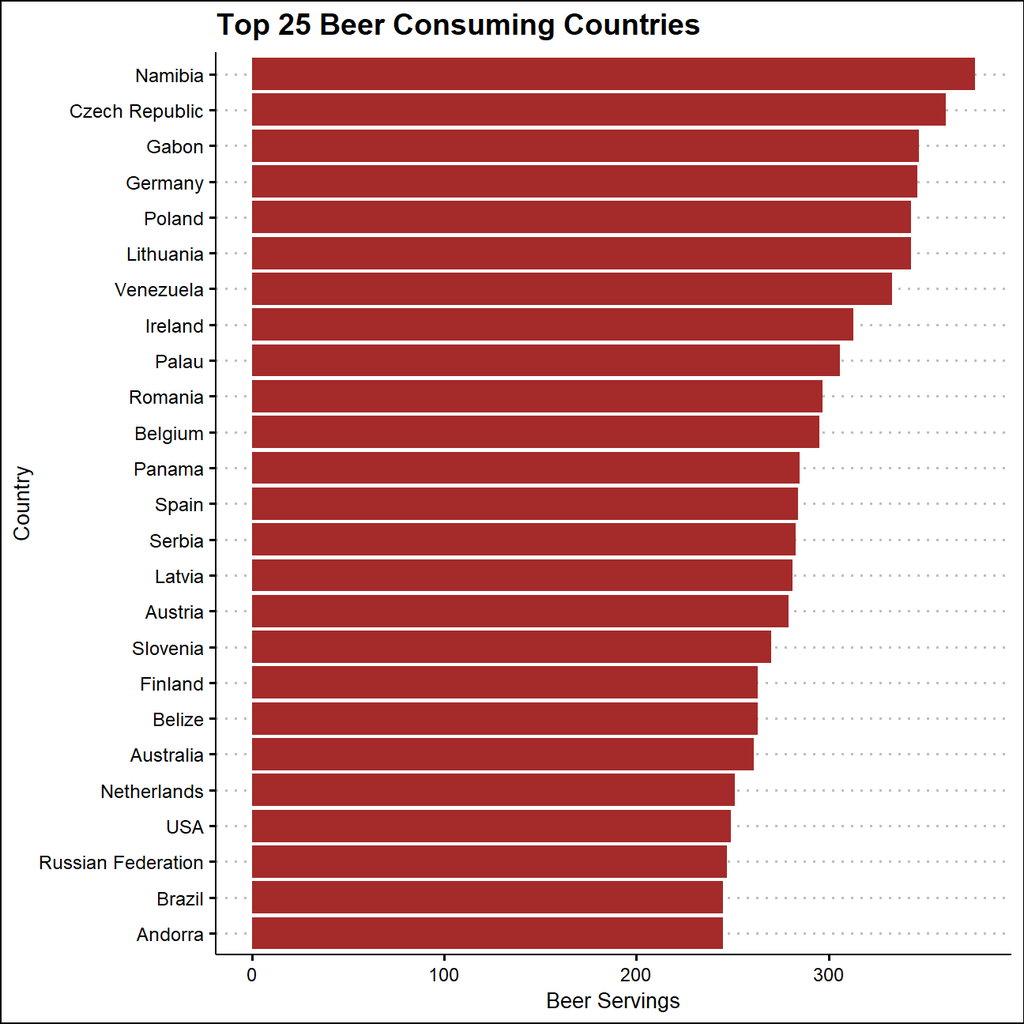

```r
desc_beer<- drinks %>%
  arrange(desc(beer_servings))

top25_beer<-head(desc_beer,25)

ggplot(top25_beer,aes(x=reorder(country,beer_servings),y=beer_servings)) + geom_col(fill="brown") + labs(x="Country", y="Beer Servings", title="Top 25 Beer Consuming Countries") + coord_flip() + theme_clean() +
  NULL
```

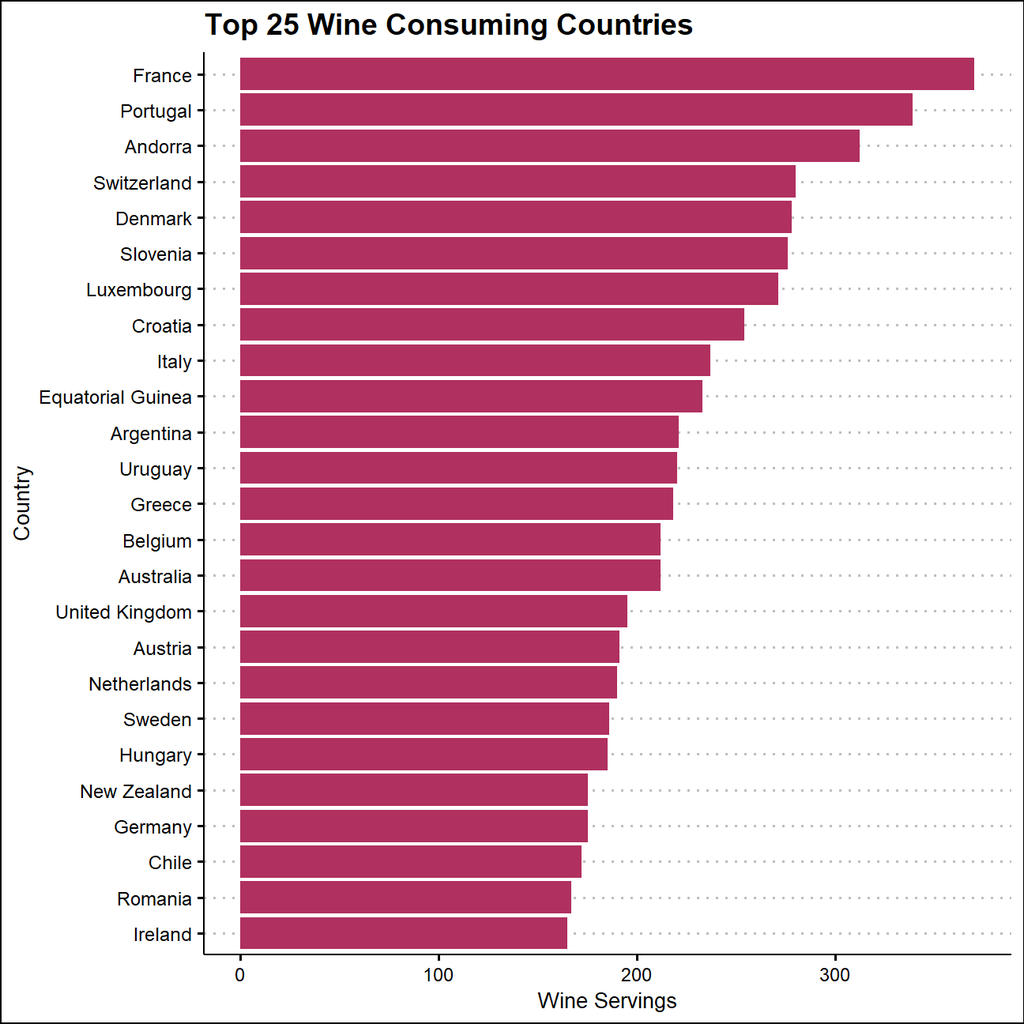

```r
desc_wine<- drinks %>%
  arrange(desc(wine_servings))

top25_wine<-head(desc_wine,25)

ggplot(top25_wine,aes(x=reorder(country,wine_servings),y=wine_servings)) + geom_col(fill="maroon") + labs(x="Country", y="Wine Servings", title="Top 25 Wine Consuming Countries") + coord_flip() + theme_clean() + NULL
```

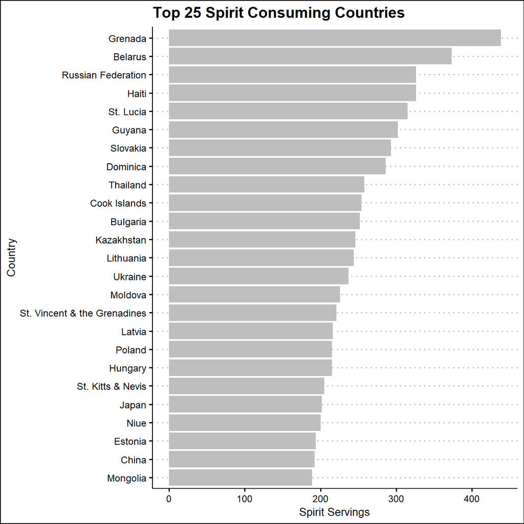

```r
desc_spirit<- drinks %>%
  arrange(desc(spirit_servings))

top25_spirit<-head(desc_spirit,25)

ggplot(top25_spirit,aes(x=reorder(country,spirit_servings),y=spirit_servings)) + geom_col(fill="grey") + labs(x="Country", y="Spirit Servings", title="Top 25 Spirit Consuming Countries") + coord_flip() + theme_clean() + NULL
```

In the first plot we can see that Namibia has the highest yearly consumption of beer per capita. Beer is one of Namibia’s most iconic commodity and their top quality brewing is a legacy of German colonialism.The second most beer-loving country is Czech Republic, known for its unique brewing methods and prevalent drinking culture. The second plot, representing wine consumption, shows that French and Portuguese drink the most wine. It is not very surprising given these are one of the most well known wine producing countries in the world. Last but not least, looking at the third plot we can see that Grenada and Belarus are the most spirit-loving countries. We can safely assume that Grenadians prefer to drink rum while Belarussians enjoy their vodka.

# 2 Analysis of movies- IMDB dataset

## 2.1 Loading the data

```
## Rows: 2,961
## Columns: 11
## $ title               <chr> "Avatar", "Titanic", "Jurassic World", "The Ave...
## $ genre               <chr> "Action", "Drama", "Action", "Action", "Action"...
## $ director            <chr> "James Cameron", "James Cameron", "Colin Trevor...
## $ year                <dbl> 2009, 1997, 2015, 2012, 2008, 1999, 1977, 2015,...
## $ duration            <dbl> 178, 194, 124, 173, 152, 136, 125, 141, 164, 93...
## $ gross               <dbl> 7.61e+08, 6.59e+08, 6.52e+08, 6.23e+08, 5.33e+0...
## $ budget              <dbl> 2.37e+08, 2.00e+08, 1.50e+08, 2.20e+08, 1.85e+0...
## $ cast_facebook_likes <dbl> 4834, 45223, 8458, 87697, 57802, 37723, 13485, ...
## $ votes               <dbl> 886204, 793059, 418214, 995415, 1676169, 534658...
## $ reviews             <dbl> 3777, 2843, 1934, 2425, 5312, 3917, 1752, 1752,...
## $ rating              <dbl> 7.9, 7.7, 7.0, 8.1, 9.0, 6.5, 8.7, 7.5, 8.5, 7....
```

Data summary

| Name | movies |
| --- | --- |
| Number of rows | 2961 |
| Number of columns | 11 |
| _______________________ |  |
| Column type frequency: |  |
| character | 3 |
| numeric | 8 |
| ________________________ |  |
| Group variables | None |

**Variable type: character**

| skim_variable | n_missing | complete_rate | min | max | empty | n_unique | whitespace |
| --- | --- | --- | --- | --- | --- | --- | --- |
| title | 0 | 1 | 1 | 83 | 0 | 2907 | 0 |
| genre | 0 | 1 | 5 | 11 | 0 | 17 | 0 |
| director | 0 | 1 | 3 | 32 | 0 | 1366 | 0 |

**Variable type: numeric**

| skim_variable | n_missing | complete_rate | mean | sd | p0 | p25 | p50 | p75 | p100 | hist |
| --- | --- | --- | --- | --- | --- | --- | --- | --- | --- | --- |
| year | 0 | 1 | 2.00e+03 | 9.95e+00 | 1920.0 | 2.00e+03 | 2.00e+03 | 2.01e+03 | 2.02e+03 | ▁▁▁▂▇ |
| duration | 0 | 1 | 1.10e+02 | 2.22e+01 | 37.0 | 9.50e+01 | 1.06e+02 | 1.19e+02 | 3.30e+02 | ▃▇▁▁▁ |
| gross | 0 | 1 | 5.81e+07 | 7.25e+07 | 703.0 | 1.23e+07 | 3.47e+07 | 7.56e+07 | 7.61e+08 | ▇▁▁▁▁ |
| budget | 0 | 1 | 4.06e+07 | 4.37e+07 | 218.0 | 1.10e+07 | 2.60e+07 | 5.50e+07 | 3.00e+08 | ▇▂▁▁▁ |
| cast_facebook_likes | 0 | 1 | 1.24e+04 | 2.05e+04 | 0.0 | 2.24e+03 | 4.60e+03 | 1.69e+04 | 6.57e+05 | ▇▁▁▁▁ |
| votes | 0 | 1 | 1.09e+05 | 1.58e+05 | 5.0 | 1.99e+04 | 5.57e+04 | 1.33e+05 | 1.69e+06 | ▇▁▁▁▁ |
| reviews | 0 | 1 | 5.03e+02 | 4.94e+02 | 2.0 | 1.99e+02 | 3.64e+02 | 6.31e+02 | 5.31e+03 | ▇▁▁▁▁ |
| rating | 0 | 1 | 6.39e+00 | 1.05e+00 | 1.6 | 5.80e+00 | 6.50e+00 | 7.10e+00 | 9.30e+00 | ▁▁▆▇▁ |

```
## [1] FALSE
```

```
## TRUE
##   54
```

## 2.2 Finding the number of movies by genre

```r
movies_clean %>%
  group_by(genre) %>%
  count(sort=TRUE)
```

```
## # A tibble: 17 x 2
## # Groups:   genre [17]
##    genre           n
##    <chr>       <int>
##  1 Comedy        844
##  2 Action        719
##  3 Drama         484
##  4 Adventure     281
##  5 Crime         198
##  6 Biography     135
##  7 Horror        128
##  8 Animation      35
##  9 Fantasy        26
## 10 Documentary    25
## 11 Mystery        15
## 12 Sci-Fi          7
## 13 Family          3
## 14 Musical         2
## 15 Romance         2
## 16 Western         2
## 17 Thriller        1
```

## 2.3 Finding the return on budget by genre

```
## # A tibble: 17 x 4
##    genre       mean_gross mean_budget return_on_budget
##    <chr>            <dbl>       <dbl>            <dbl>
##  1 Musical      92084000     3189500          28.9
##  2 Family      149160478.   14833333.         10.1
##  3 Western      20821884     3465000           6.01
##  4 Documentary  17353973.    5887852.          2.95
##  5 Horror       37782310.   13804379.          2.74
##  6 Fantasy      41902674.   18484615.          2.27
##  7 Comedy       42487808.   24458506.          1.74
##  8 Mystery      69117136.   41500000           1.67
##  9 Animation    98433792.   61701429.          1.60
## 10 Biography    45201805.   28543696.          1.58
## 11 Adventure    94350236.   64692313.          1.46
## 12 Drama        36754959.   25832605.          1.42
## 13 Crime        37601525.   26527405.          1.42
## 14 Romance      31264848.   25107500           1.25
## 15 Action       86270343.   70774558.          1.22
## 16 Sci-Fi       29788371.   27607143.          1.08
## 17 Thriller         2468      300000           0.00823
```

## 2.4 Finding the top 15 directors by gross earnings

```
## # A tibble: 15 x 6
##    director          total_gross mean_gross median_gross   sd_gross count
##    <chr>                   <dbl>      <dbl>        <dbl>      <dbl> <int>
##  1 Steven Spielberg   4014061704 174524422.   164435221  101421051.    23
##  2 Michael Bay        2195443511 182953626.   168468240. 125789167.    12
##  3 James Cameron      1909725910 318287652.   175562880. 309171337.     6
##  4 Christopher Nolan  1813227576 226653447    196667606. 187224133.     8
##  5 George Lucas       1741418480 348283696    380262555  146193880.     5
##  6 Robert Zemeckis    1619309108 124562239.   100853835   91300279.    13
##  7 Tim Burton         1557078534 111219895.    69791834   99304293.    14
##  8 Sam Raimi          1443167519 180395940.   138480208  174705230.     8
##  9 Clint Eastwood     1378321100  72543216.    46700000   75487408.    19
## 10 Francis Lawrence   1358501971 271700394.   281666058  135437020.     5
## 11 Ron Howard         1335988092 111332341    101587923   81933761.    12
## 12 Gore Verbinski     1329600995 189942999.   123207194  154473822.     7
## 13 Andrew Adamson     1137446920 284361730    279680930. 120895765.     4
## 14 Shawn Levy         1129750988 102704635.    85463309   65484773.    11
## 15 Ridley Scott       1128857598  80632686.    47775715   68812285.    14
```

## 2.5 Summary statistics of movie ratings by genre and plotting a histogram

```
## # A tibble: 17 x 6
##    genre       mean_rating median_rating max_rating min_rating sd_rating
##    <chr>             <dbl>         <dbl>      <dbl>      <dbl>     <dbl>
##  1 Action             6.23          6.3         9          2.1     1.04
##  2 Adventure          6.51          6.6         8.6        2.3     1.11
##  3 Animation          6.65          6.9         8          4.5     0.968
##  4 Biography          7.11          7.2         8.9        4.5     0.760
##  5 Comedy             6.11          6.2         8.8        1.9     1.02
##  6 Crime              6.92          6.9         9.3        4.8     0.853
##  7 Documentary        6.66          7.4         8.5        1.6     1.77
##  8 Drama              6.74          6.8         8.8        2.1     0.915
##  9 Family             6.5           5.9         7.9        5.7     1.22
## 10 Fantasy            6.08          6.2         7.9        4.3     0.953
## 11 Horror             5.79          5.85        8.5        3.6     0.987
## 12 Musical            6.75          6.75        7.2        6.3     0.636
## 13 Mystery            6.84          6.7         8.5        4.6     0.910
## 14 Romance            6.65          6.65        7.1        6.2     0.636
## 15 Sci-Fi             6.66          6.4         8.2        5       1.09
## 16 Thriller           4.8           4.8         4.8        4.8    NA
## 17 Western            5.70          5.70        7.3        4.1     2.26
```

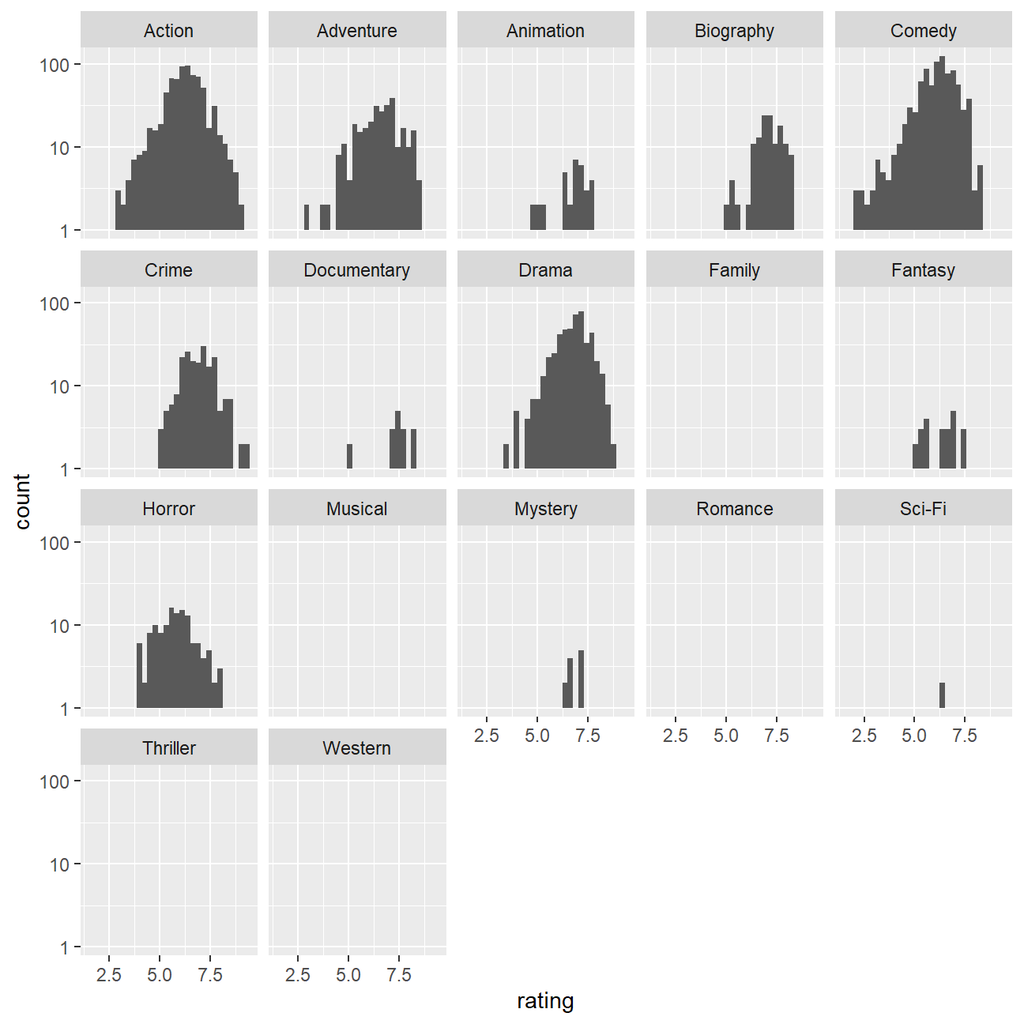

## Use `ggplot` to answer the following

- Examine the relationship between `gross` and `cast_facebook_likes`. Produce a scatterplot and write one sentence discussing whether the number of facebook likes that the cast has received is likely to be a good predictor of how much money a movie will make at the box office. What variable are you going to map to the Y- and X- axes?

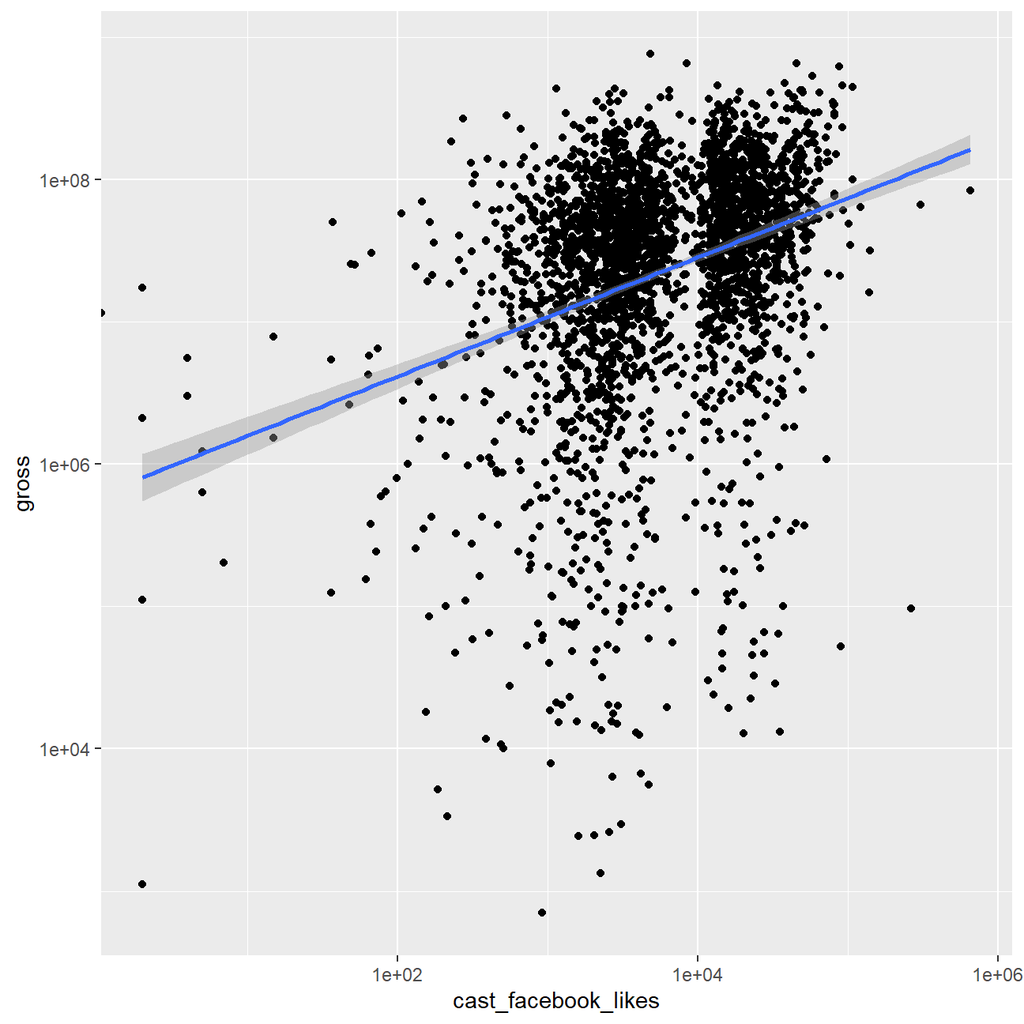

## Comment gross_fblikes

We chose the Gross as the Y-variable and the Facebook Likes as the X-variable because we believed Gross to be the dependent variable and Facebook Likes the independent one. On average, the number of facebook likes seems to be a good predictor of how well a movie will fare in the box office, however, there are many data points which lie outside this observation and which prove that this isn’t always the case.

- Examine the relationship between `gross` and `budget`. Produce a scatterplot and write one sentence discussing whether budget is likely to be a good predictor of how much money a movie will make at the box office.

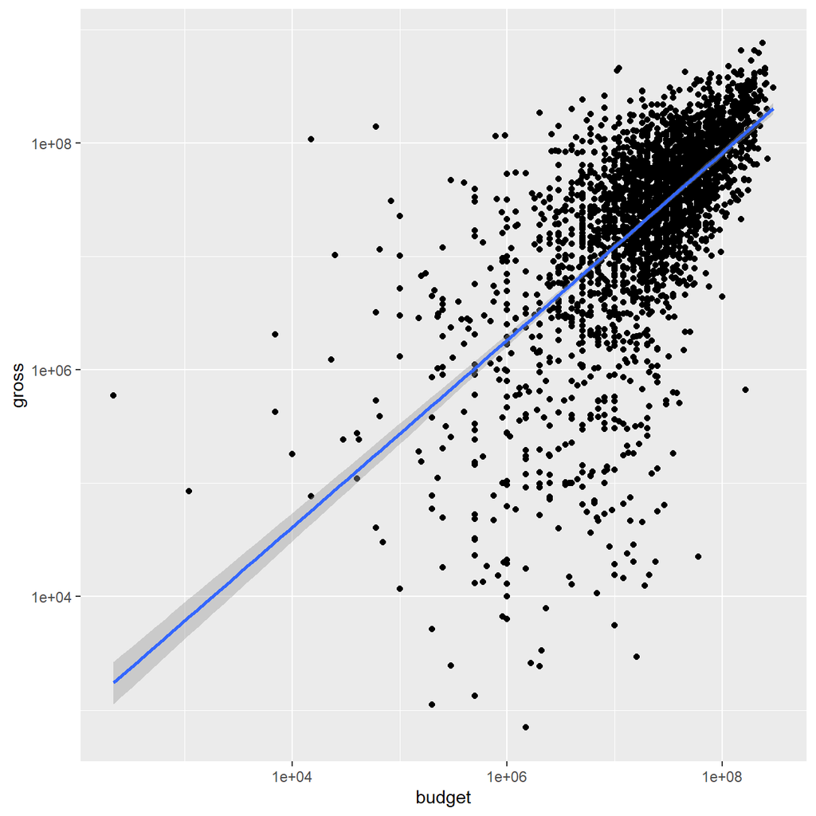

```r
ggplot(data = movies_clean, mapping = aes(x = budget, y = gross)) + geom_point() + geom_smooth(method=lm) +  scale_x_log10()  + scale_y_log10() + NULL
```

## Comment gross_budget

The tendency seems to indicate that the bigger the budget, the higher the movie will gross. This is especially true for movies with high budgets as we see a concentration of datapoints at that level. Some dataponts indicate that it is not always the case as many movies fall outside this high budget - high gross correlation. However, the overarching sense is that budget is likely to be a good predictor of how much money a movie will make at the box office.

- Examine the relationship between `gross` and `rating`. Produce a scatterplot, faceted by `genre` and discuss whether IMDB ratings are likely to be a good predictor of how much money a movie will make at the box office. Is there anything strange in this dataset?

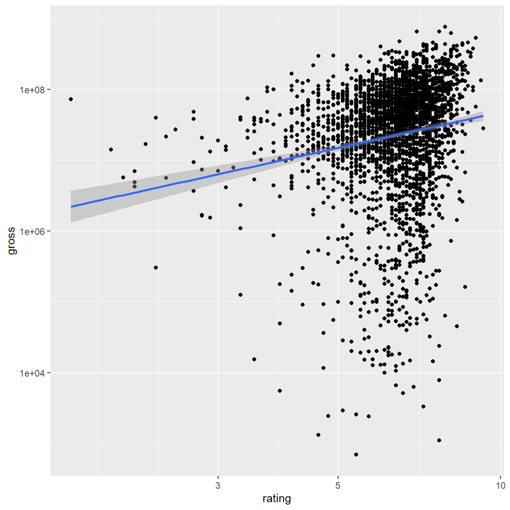

```r
ggplot(data = movies_clean, mapping = aes(x = rating, y = gross)) + geom_point() + geom_smooth(method=lm) +  scale_x_log10()  + scale_y_log10() + NULL
```

## Comment Gross_IMDB

According to the datapoints, IMDB ratings tend to be higher for movies which have grossed highly indicating that IMDB ratings could be a good predictor of how much a movie will make. In reality however, its much more complicated to determine if IMDB scores are high because a movie has grossed highly, in which case it isn’t so much a correlation as a causality.

# 3 Returns of financial stocks

## 3.1 Loading the dataset

```r
#Loading the NYSE dataset
nyse <- read_csv(here::here("data","nyse.csv"))
nyse %>%
glimpse %>%
skim
```

```
## Rows: 508
## Columns: 6
## $ symbol        <chr> "MMM", "ABB", "ABT", "ABBV", "ACN", "AAP", "AFL", "A"...
## $ name          <chr> "3M Company", "ABB Ltd", "Abbott Laboratories", "AbbV...
## $ ipo_year      <chr> "n/a", "n/a", "n/a", "2012", "2001", "n/a", "n/a", "1...
## $ sector        <chr> "Health Care", "Consumer Durables", "Health Care", "H...
## $ industry      <chr> "Medical/Dental Instruments", "Electrical Products", ...
## $ summary_quote <chr> "https://www.nasdaq.com/symbol/mmm", "https://www.nas...
```

Data summary

| Name | Piped data |
| --- | --- |
| Number of rows | 508 |
| Number of columns | 6 |
| _______________________ |  |
| Column type frequency: |  |
| character | 6 |
| ________________________ |  |
| Group variables | None |

**Variable type: character**

| skim_variable | n_missing | complete_rate | min | max | empty | n_unique | whitespace |
| --- | --- | --- | --- | --- | --- | --- | --- |
| symbol | 0 | 1 | 1 | 4 | 0 | 508 | 0 |
| name | 0 | 1 | 5 | 48 | 0 | 505 | 0 |
| ipo_year | 0 | 1 | 3 | 4 | 0 | 33 | 0 |
| sector | 0 | 1 | 6 | 21 | 0 | 12 | 0 |
| industry | 0 | 1 | 5 | 62 | 0 | 103 | 0 |
| summary_quote | 0 | 1 | 31 | 34 | 0 | 508 | 0 |

## 3.2 Creating a graph to summarise the companies by sector

```r
#Showing a table of NYSE companies grouped by sector, in descending order
companies_by_sector <- nyse %>%
  group_by(sector) %>%
  summarise(number_of_companies = n()) %>%
  arrange(desc(number_of_companies))
companies_by_sector
```

```
## # A tibble: 12 x 2
##    sector                number_of_companies
##    <chr>                               <int>
##  1 Finance                                97
##  2 Consumer Services                      79
##  3 Public Utilities                       60
##  4 Capital Goods                          45
##  5 Health Care                            45
##  6 Energy                                 42
##  7 Technology                             40
##  8 Basic Industries                       39
##  9 Consumer Non-Durables                  31
## 10 Miscellaneous                          12
## 11 Transportation                         10
## 12 Consumer Durables                       8
```

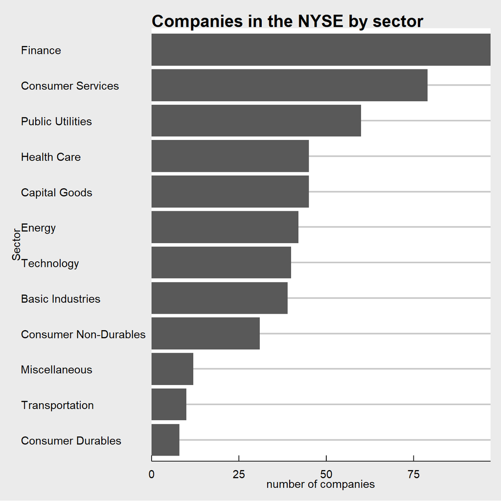

```r
#Creating a graph of NYSE companies grouped by sector
ggplot(data = companies_by_sector, mapping = aes(x=number_of_companies, y=reorder(sector,number_of_companies))) + labs(title="Companies in the NYSE by sector",y="Sector", x="number of companies") + geom_col() + theme_economist_white() + scale_x_continuous(expand = c(0,0))
```

## Finding stock prices for 8 securities

```r
myStocks <- c("AAPL","JPM","DIS","DPZ","ANF","TSLA","XOM","SPY" ) %>%
  tq_get(get  = "stock.prices",
         from = "2010-01-01",
         to   = "2020-09-25") %>%
  group_by(symbol)
# examine the structure of the resulting data frame
myStocks %>%
  glimpse
```

```
## Rows: 21,486
## Columns: 8
## Groups: symbol [8]
## $ symbol   <chr> "AAPL", "AAPL", "AAPL", "AAPL", "AAPL", "AAPL", "AAPL", "A...
## $ date     <date> 2010-01-04, 2010-01-05, 2010-01-06, 2010-01-07, 2010-01-0...
## $ open     <dbl> 7.62, 7.66, 7.66, 7.56, 7.51, 7.60, 7.47, 7.42, 7.50, 7.53...
## $ high     <dbl> 7.66, 7.70, 7.69, 7.57, 7.57, 7.61, 7.49, 7.53, 7.52, 7.56...
## $ low      <dbl> 7.58, 7.62, 7.53, 7.47, 7.47, 7.44, 7.37, 7.29, 7.46, 7.35...
## $ close    <dbl> 7.64, 7.66, 7.53, 7.52, 7.57, 7.50, 7.42, 7.52, 7.48, 7.35...
## $ volume   <dbl> 4.94e+08, 6.02e+08, 5.52e+08, 4.77e+08, 4.48e+08, 4.62e+08...
## $ adjusted <dbl> 6.60, 6.62, 6.51, 6.50, 6.54, 6.48, 6.41, 6.50, 6.46, 6.36...
```

```r
#Calculating daily returns
myStocks_daily_returns <- myStocks %>%
  tq_transmute(select     = adjusted,
               mutate_fun = periodReturn,
               period     = "daily",
               type       = "log",
               col_rename = "daily_returns",
               cols = c(nested.col))

#Calculating monthly  returns
myStocks_monthly_returns <- myStocks %>%
  tq_transmute(select     = adjusted,
               mutate_fun = periodReturn,
               period     = "monthly",
               type       = "arithmetic",
               col_rename = "monthly_returns",
               cols = c(nested.col))

#Calculating yearly returns
myStocks_annual_returns <- myStocks %>%
  group_by(symbol) %>%
  tq_transmute(select     = adjusted,
               mutate_fun = periodReturn,
               period     = "yearly",
               type       = "arithmetic",
               col_rename = "yearly_returns",
               cols = c(nested.col))

#Printing the returns calculated above
myStocks_daily_returns
```

```
## # A tibble: 21,486 x 3
## # Groups:   symbol [8]
##    symbol date       daily_returns
##    <chr>  <date>             <dbl>
##  1 AAPL   2010-01-04       0
##  2 AAPL   2010-01-05       0.00173
##  3 AAPL   2010-01-06      -0.0160
##  4 AAPL   2010-01-07      -0.00185
##  5 AAPL   2010-01-08       0.00663
##  6 AAPL   2010-01-11      -0.00886
##  7 AAPL   2010-01-12      -0.0114
##  8 AAPL   2010-01-13       0.0140
##  9 AAPL   2010-01-14      -0.00581
## 10 AAPL   2010-01-15      -0.0169
## # ... with 21,476 more rows
```

```r
myStocks_monthly_returns
```

```
## # A tibble: 1,027 x 3
## # Groups:   symbol [8]
##    symbol date       monthly_returns
##    <chr>  <date>               <dbl>
##  1 AAPL   2010-01-29         -0.103
##  2 AAPL   2010-02-26          0.0654
##  3 AAPL   2010-03-31          0.148
##  4 AAPL   2010-04-30          0.111
##  5 AAPL   2010-05-28         -0.0161
##  6 AAPL   2010-06-30         -0.0208
##  7 AAPL   2010-07-30          0.0227
##  8 AAPL   2010-08-31         -0.0550
##  9 AAPL   2010-09-30          0.167
## 10 AAPL   2010-10-29          0.0607
## # ... with 1,017 more rows
```

```r
myStocks_annual_returns
```

```
## # A tibble: 88 x 3
## # Groups:   symbol [8]
##    symbol date       yearly_returns
##    <chr>  <date>              <dbl>
##  1 AAPL   2010-12-31         0.507
##  2 AAPL   2011-12-30         0.256
##  3 AAPL   2012-12-31         0.326
##  4 AAPL   2013-12-31         0.0807
##  5 AAPL   2014-12-31         0.406
##  6 AAPL   2015-12-31        -0.0301
##  7 AAPL   2016-12-30         0.125
##  8 AAPL   2017-12-29         0.485
##  9 AAPL   2018-12-31        -0.0539
## 10 AAPL   2019-12-31         0.890
## # ... with 78 more rows
```

## 3.3 Summarising monthly returns

```r
monthly_returns <- myStocks_monthly_returns %>%
  summarise(mean_return=mean(monthly_returns, na.rm=TRUE), median_return=median(monthly_returns, na.rm=TRUE), max_return=max(monthly_returns, na.rm=TRUE), min_return=min(monthly_returns, na.rm=TRUE), sd_return=sd(monthly_returns, na.rm=TRUE))

monthly_returns
```

```
## # A tibble: 8 x 6
##   symbol mean_return median_return max_return min_return sd_return
##   <chr>        <dbl>         <dbl>      <dbl>      <dbl>     <dbl>
## 1 AAPL      0.0251        0.0277        0.217     -0.181    0.0803
## 2 ANF       0.00573       0.000403      0.507     -0.421    0.141
## 3 DIS       0.0136        0.0118        0.234     -0.179    0.0644
## 4 DPZ       0.0347        0.0284        0.342     -0.188    0.0798
## 5 JPM       0.0108        0.0180        0.172     -0.229    0.0726
## 6 SPY       0.0107        0.0155        0.127     -0.125    0.0404
## 7 TSLA      0.0502        0.0117        0.811     -0.246    0.183
## 8 XOM      -0.000659      0.00161       0.224     -0.262    0.0600
```

## 3.4 Plotting a density plot for each stock

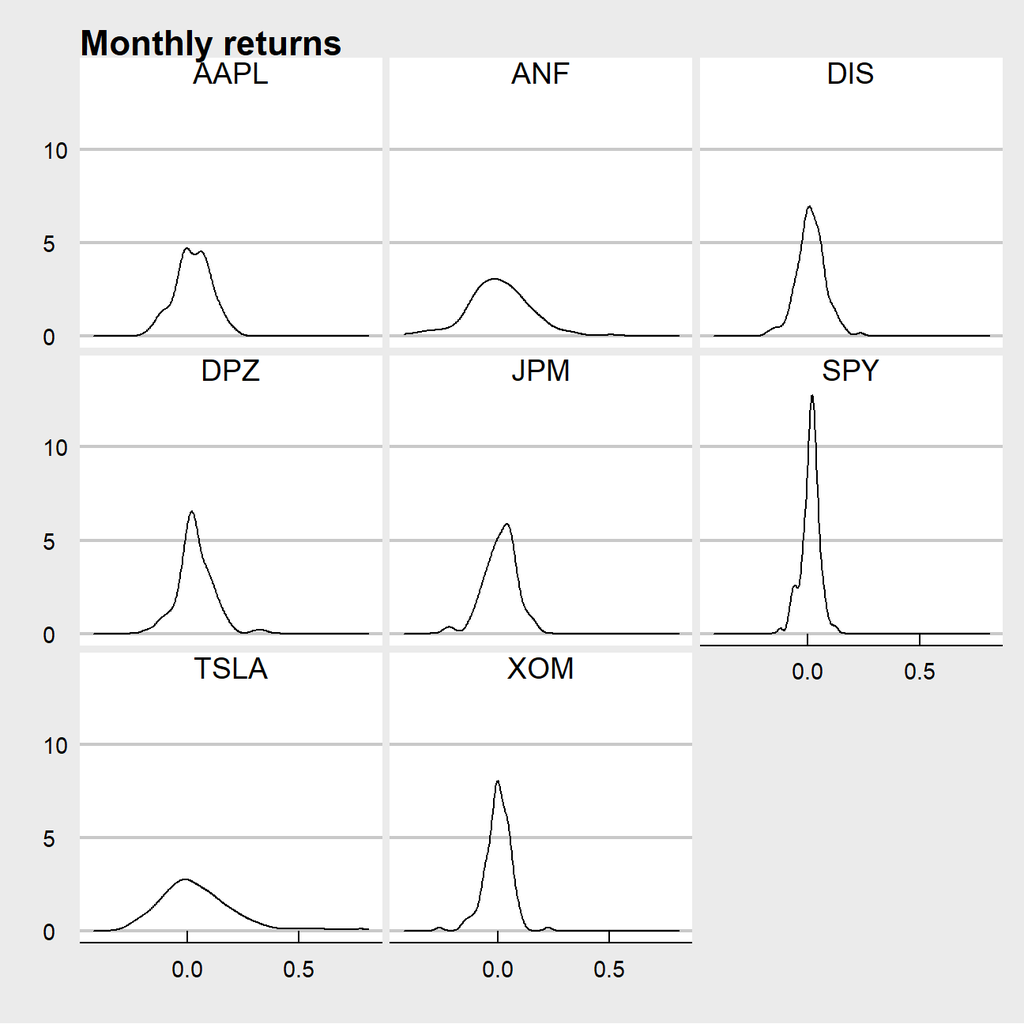

```r
dp <- ggplot(data = myStocks_monthly_returns, mapping = aes(x=monthly_returns)) + labs(title="Monthly returns",y="", x="") + geom_density() + theme_economist_white() + facet_wrap(~ symbol)
dp
```

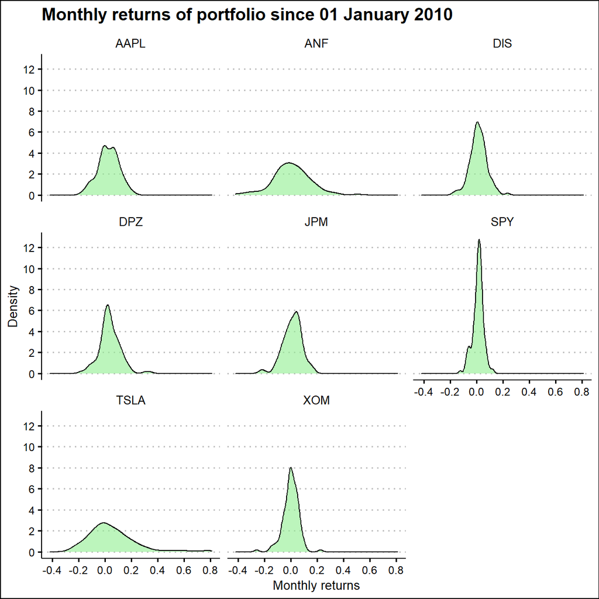

```r
ggplot(myStocks_monthly_returns, aes(x=monthly_returns)) +
  geom_density(fill = "lightgreen", alpha = 0.6) +
  labs(title = "Monthly returns of portfolio since 01 January 2010", x = "Monthly returns", y = "Density") +
  scale_x_continuous(breaks = scales::pretty_breaks(n = 8)) +
  scale_y_continuous(breaks = scales::pretty_breaks(n = 8)) +
  facet_wrap(~symbol, scales='fixed') +
  theme_clean()
```

## 3.5 Comment on riskiness of selected securities

We can infer that Tesla (TSLA) is the most risky stock given it has the highest standard deviation, displayed by its monthly returns having the fattest tails and shortest peak at the mean value. By contrast, SPY (S&P500 ETF) appears the least risky stock given it displays the lowest standard deviation when comparing monthly returns.

## 3.6 Plotting risk and reward for a stock

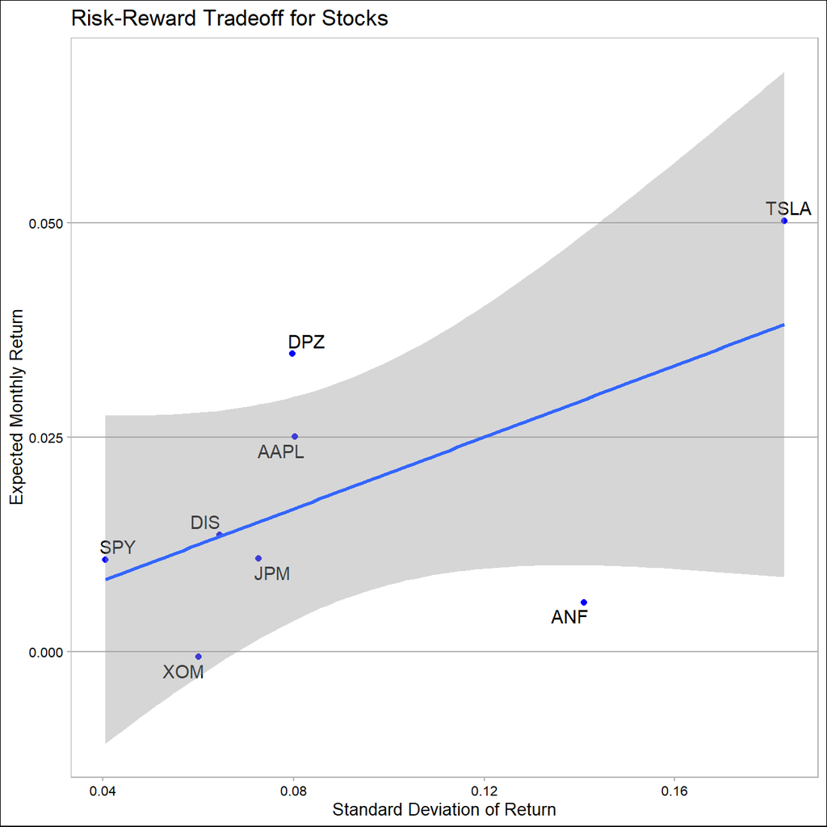

```r
library(ggrepel)
risk_return <- ggplot(data = monthly_returns, mapping = aes(y=mean_return, x=sd_return, label = symbol)) + geom_point(color = "blue")

p <- risk_return + geom_text_repel(aes(label=symbol)) + labs(title = "Risk-Reward Tradeoff for Stocks", x="Standard Deviation of Return", y="Expected Monthly Return") + geom_smooth(method=lm) + theme_calc()
p
```

## Comment on above graph

From the graph we can see that ANF is the furthest below the trend line, indicating that its returns are much less than expected given the risk a shareholders bears when holding this stock. On the other hand, DPZ seems to strongly outperform given its riskiness.

# 4 On your own: IBM HR Analytics

First let us load the data

```r
hr_dataset <- read_csv(here::here("data", "datasets_1067_1925_WA_Fn-UseC_-HR-Employee-Attrition.csv"))
glimpse(hr_dataset)
```

```
## Rows: 1,470
## Columns: 35
## $ Age                      <dbl> 41, 49, 37, 33, 27, 32, 59, 30, 38, 36, 35...
## $ Attrition                <chr> "Yes", "No", "Yes", "No", "No", "No", "No"...
## $ BusinessTravel           <chr> "Travel_Rarely", "Travel_Frequently", "Tra...
## $ DailyRate                <dbl> 1102, 279, 1373, 1392, 591, 1005, 1324, 13...
## $ Department               <chr> "Sales", "Research & Development", "Resear...
## $ DistanceFromHome         <dbl> 1, 8, 2, 3, 2, 2, 3, 24, 23, 27, 16, 15, 2...
## $ Education                <dbl> 2, 1, 2, 4, 1, 2, 3, 1, 3, 3, 3, 2, 1, 2, ...
## $ EducationField           <chr> "Life Sciences", "Life Sciences", "Other",...
## $ EmployeeCount            <dbl> 1, 1, 1, 1, 1, 1, 1, 1, 1, 1, 1, 1, 1, 1, ...
## $ EmployeeNumber           <dbl> 1, 2, 4, 5, 7, 8, 10, 11, 12, 13, 14, 15, ...
## $ EnvironmentSatisfaction  <dbl> 2, 3, 4, 4, 1, 4, 3, 4, 4, 3, 1, 4, 1, 2, ...
## $ Gender                   <chr> "Female", "Male", "Male", "Female", "Male"...
## $ HourlyRate               <dbl> 94, 61, 92, 56, 40, 79, 81, 67, 44, 94, 84...
```

[output cut: 22 more lines]

I am going to clean the data set, as variable names are in capital letters, some variables are not really necessary, and some variables, e.g., `education` are given as a number rather than a more useful description

```r
hr_cleaned <- hr_dataset %>%
  clean_names() %>%
  mutate(
    education = case_when(
      education == 1 ~ "Below College",
      education == 2 ~ "College",
      education == 3 ~ "Bachelor",
      education == 4 ~ "Master",
      education == 5 ~ "Doctor"
    ),
    environment_satisfaction = case_when(
      environment_satisfaction == 1 ~ "Low",
      environment_satisfaction == 2 ~ "Medium",
      environment_satisfaction == 3 ~ "High",
      environment_satisfaction == 4 ~ "Very High"
    ),
    job_satisfaction = case_when(
      job_satisfaction == 1 ~ "Low",
      job_satisfaction == 2 ~ "Medium",
      job_satisfaction == 3 ~ "High",
      job_satisfaction == 4 ~ "Very High"
    ),
    performance_rating = case_when(
      performance_rating == 1 ~ "Low",
      performance_rating == 2 ~ "Good",
      performance_rating == 3 ~ "Excellent",
      performance_rating == 4 ~ "Outstanding"
    ),
    work_life_balance = case_when(
      work_life_balance == 1 ~ "Bad",
      work_life_balance == 2 ~ "Good",
      work_life_balance == 3 ~ "Better",
      work_life_balance == 4 ~ "Best"
    )
  ) %>%
  select(age, attrition, daily_rate, department,
         distance_from_home, education,
         gender, job_role,environment_satisfaction,
         job_satisfaction, marital_status,
         monthly_income, num_companies_worked, percent_salary_hike,
         performance_rating, total_working_years,
         work_life_balance, years_at_company,
         years_since_last_promotion)
```

## 4.1 Attrition of employees

```r
count(hr_cleaned, attrition == "Yes")
```

```
## # A tibble: 2 x 2
##   `attrition == "Yes"`     n
##   <lgl>                <int>
## 1 FALSE                 1233
## 2 TRUE                   237
```

```r
attrition_rate <- hr_cleaned %>%
  count(hr_cleaned$attrition) %>%
  mutate(n/sum(n)*100)

attrition_rate
```

```
## # A tibble: 2 x 3
##   `hr_cleaned$attrition`     n `n/sum(n) * 100`
##   <chr>                  <int>            <dbl>
## 1 No                      1233             83.9
## 2 Yes                      237             16.1
```

The data shows that rate of attrition is 16.1%. In absolute numbers, it’s 237 of 1470.

## 4.2 Analysis of distribution of key employee data

```r
#Analysis with help of a table

distribution_keyvalues <- hr_cleaned %>%
  summarise(mean_age=mean(age, na.rm=TRUE), median_age=median(age, na.rm=TRUE), max_age=max(age, na.rm=TRUE), min_age=min(age, na.rm=TRUE), sd_age=sd(age, na.rm=TRUE), mean_years_at_company=mean(years_at_company, na.rm=TRUE), median_years_at_company=median(years_at_company, na.rm=TRUE), max_years_at_company=max(years_at_company, na.rm=TRUE), min_years_at_company=min(years_at_company, na.rm=TRUE), sd_years_at_company=sd(years_at_company, na.rm=TRUE), mean_monthly_income=mean(monthly_income, na.rm=TRUE), median_monthly_income=median(monthly_income, na.rm=TRUE), max_monthly_income=max(monthly_income, na.rm=TRUE), min_monthly_income=min(monthly_income, na.rm=TRUE), sd_monthly_income=sd(monthly_income, na.rm=TRUE), mean_years_since_last_promotion=mean(years_since_last_promotion, na.rm=TRUE), median_years_since_last_promotion=median(years_since_last_promotion, na.rm=TRUE), max_years_since_last_promotion=max(years_since_last_promotion, na.rm=TRUE), min_years_since_last_promotion=min(years_since_last_promotion, na.rm=TRUE), sd_years_since_last_promotion=sd(years_since_last_promotion, na.rm=TRUE))

distribution_keyvalues
```

```
## # A tibble: 1 x 20
##   mean_age median_age max_age min_age sd_age mean_years_at_c~ median_years_at~
##      <dbl>      <dbl>   <dbl>   <dbl>  <dbl>            <dbl>            <dbl>
## 1     36.9         36      60      18   9.14             7.01                5
## # ... with 13 more variables: max_years_at_company <dbl>,
## #   min_years_at_company <dbl>, sd_years_at_company <dbl>,
## #   mean_monthly_income <dbl>, median_monthly_income <dbl>,
## #   max_monthly_income <dbl>, min_monthly_income <dbl>,
## #   sd_monthly_income <dbl>, mean_years_since_last_promotion <dbl>,
## #   median_years_since_last_promotion <dbl>,
## #   max_years_since_last_promotion <dbl>, min_years_since_last_promotion <dbl>,
## #   sd_years_since_last_promotion <dbl>
```

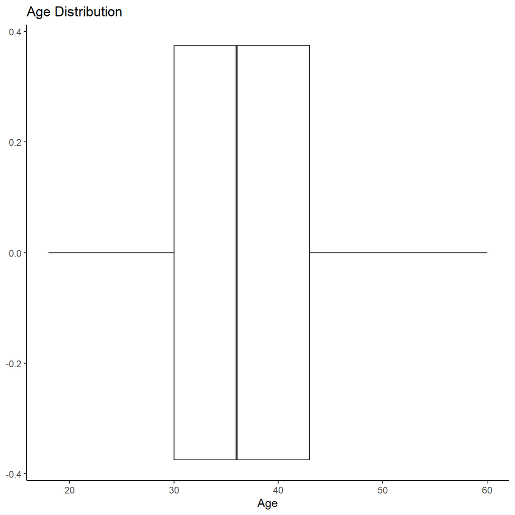

```r
#Analysis with the help of graphs

ggplot(hr_cleaned, aes(x=age)) +
  labs(title = "Age Distribution",  x = "Age") +
  geom_boxplot() +
  theme_classic()
```

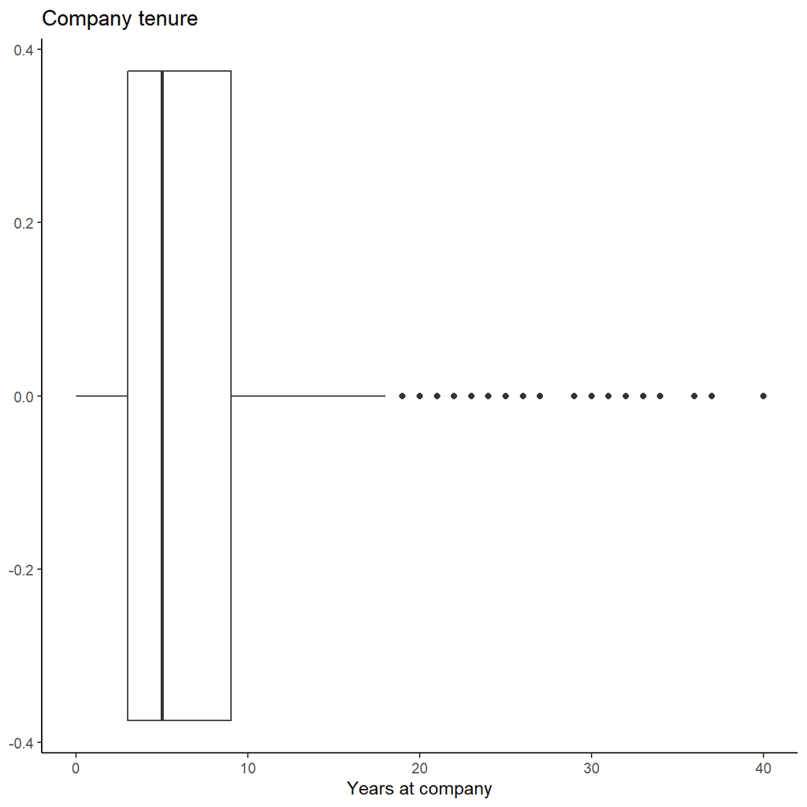

```r
ggplot(hr_cleaned,aes(x=years_at_company)) +
  labs(title = "Company tenure",  x = "Years at company") +
  geom_boxplot() +
  theme_classic()
```

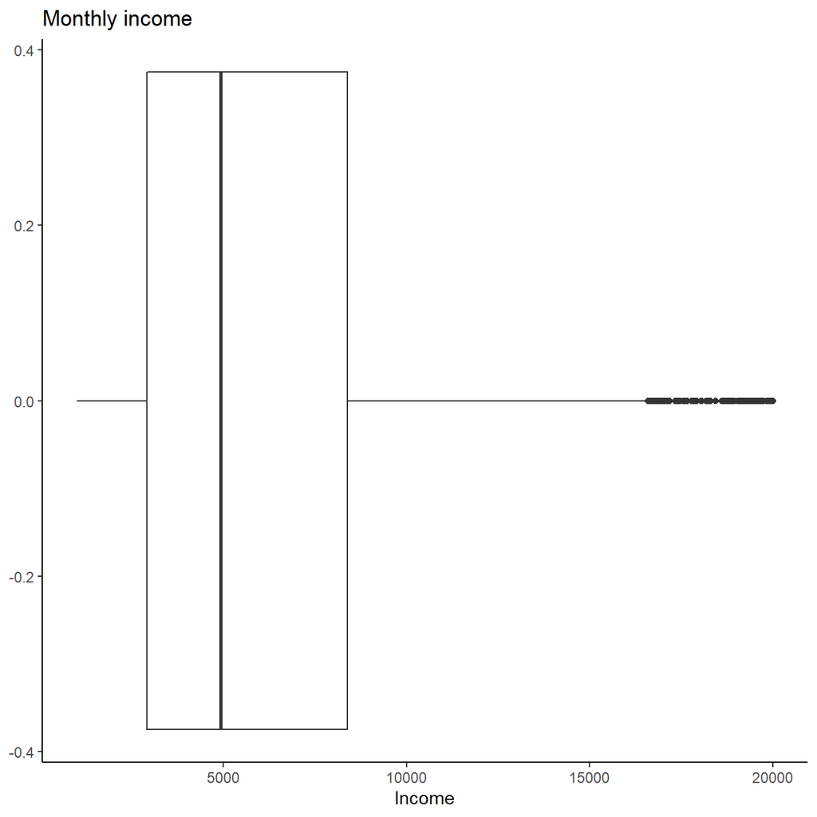

```r
ggplot(hr_cleaned,aes(x=monthly_income)) +
  labs(title = "Monthly income",  x = "Income") +
  geom_boxplot() +
  theme_classic()
```

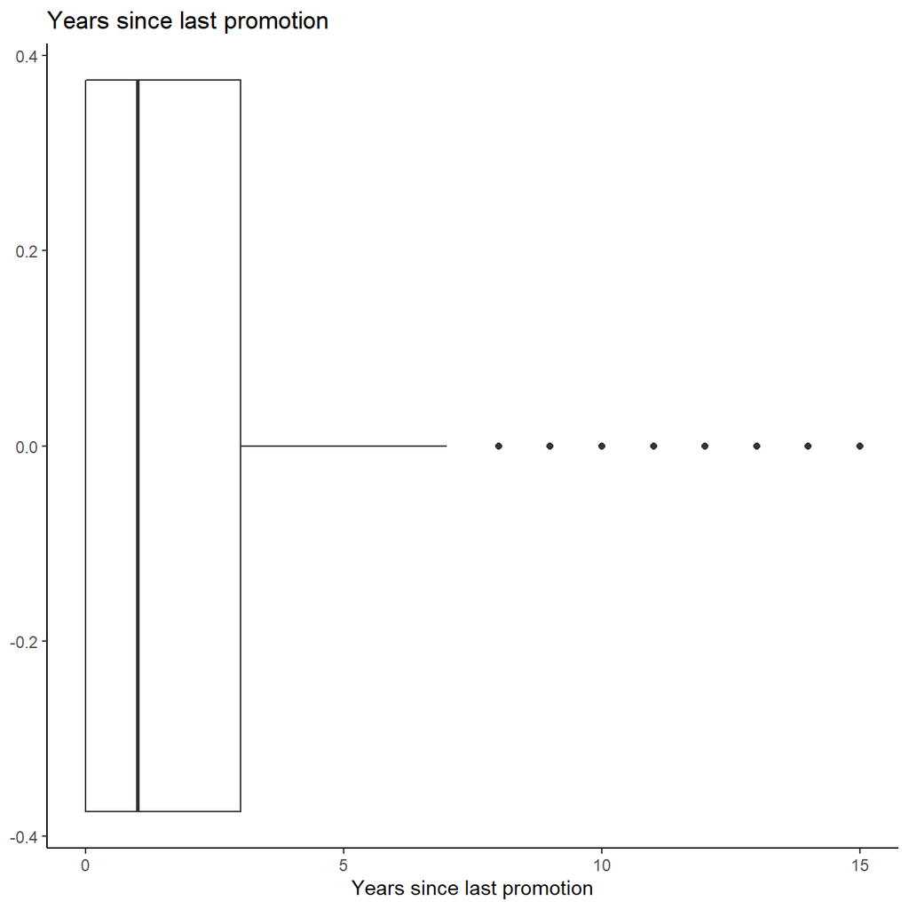

```r
ggplot(hr_cleaned,aes(x=years_since_last_promotion)) +
  labs(title = "Years since last promotion",  x = "Years since last promotion") +
  geom_boxplot() +
  theme_classic()
```

Looking at all graphs it appears that the age distribution is most similar to a normal distribution. This is also reflected by relatively similar median and mean values for age shown in the table . All other distributions are skewed to the right.

## 4.3 Job satisfaction and work life balance

```r
job_satisfaction_ibm <- hr_cleaned %>%
  group_by(job_satisfaction) %>%
  count() %>%
  ungroup() %>%
  mutate(pct_job_satisfaction = 100*n/sum(n))

job_satisfaction_ibm
```

```
## # A tibble: 4 x 3
##   job_satisfaction     n pct_job_satisfaction
##   <chr>            <int>                <dbl>
## 1 High               442                 30.1
## 2 Low                289                 19.7
## 3 Medium             280                 19.0
## 4 Very High          459                 31.2
```

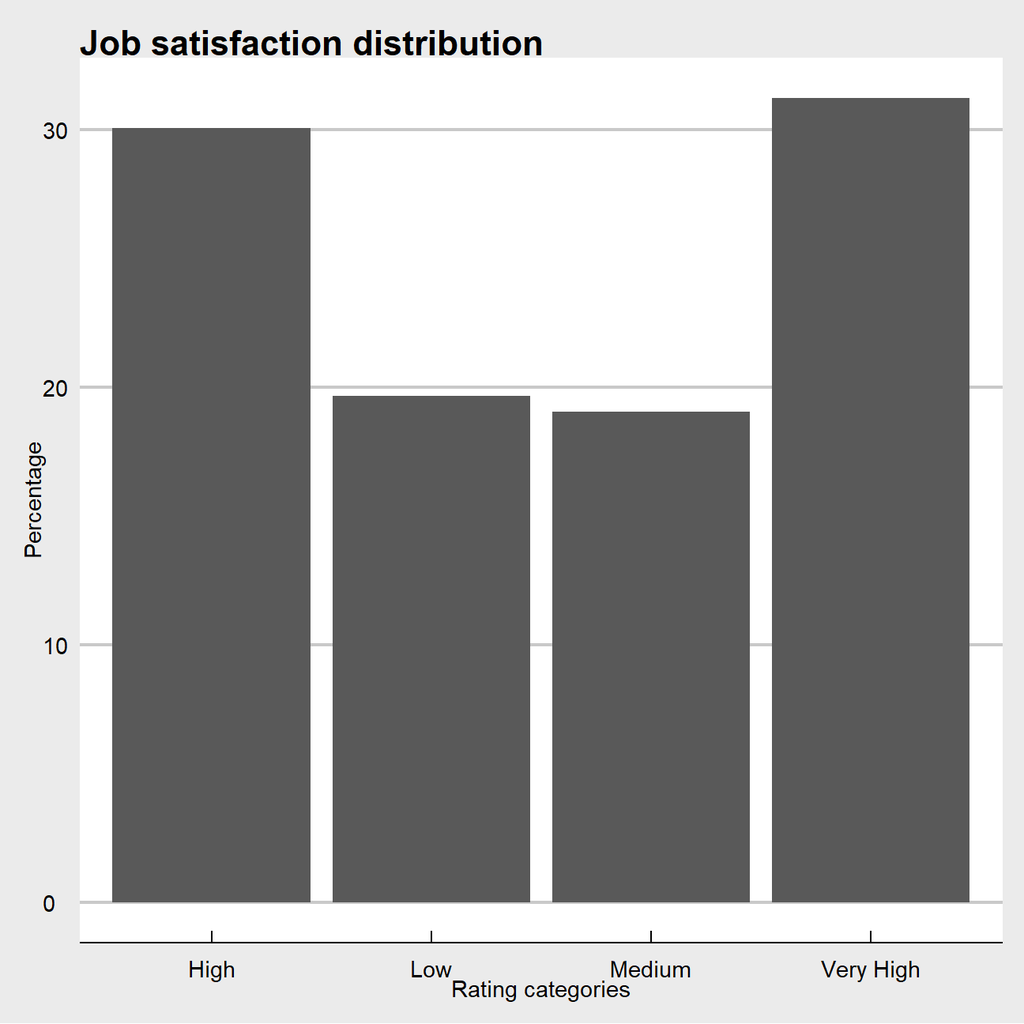

```r
ggplot(data = job_satisfaction_ibm, mapping =aes(x = job_satisfaction, y = pct_job_satisfaction)) + geom_col() + labs(title = "Job satisfaction distribution",  x = "Rating categories", y = "Percentage") + theme_economist_white() + NULL
```

```r
wl_balance <- hr_cleaned %>%
  group_by(work_life_balance) %>%
  count() %>%
  ungroup() %>%
  mutate(pct_work_life_balance = 100*n/sum(n))

wl_balance
```

```
## # A tibble: 4 x 3
##   work_life_balance     n pct_work_life_balance
##   <chr>             <int>                 <dbl>
## 1 Bad                  80                  5.44
## 2 Best                153                 10.4
## 3 Better              893                 60.7
## 4 Good                344                 23.4
```

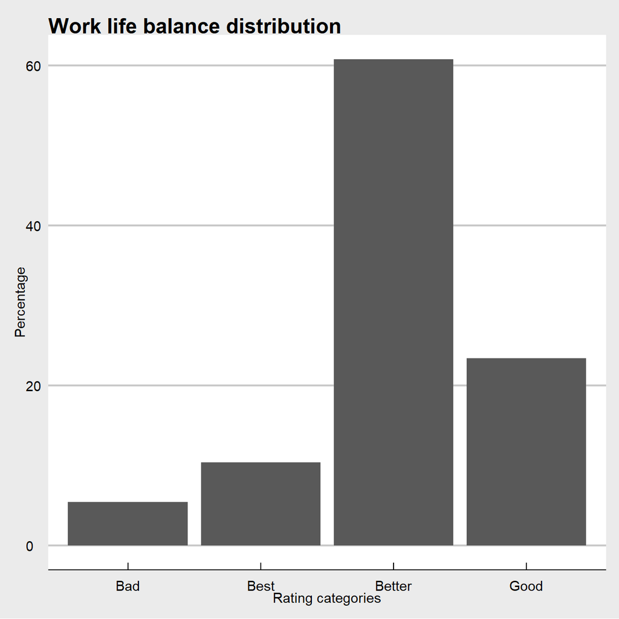

```r
ggplot(data = wl_balance, mapping =aes(x = work_life_balance, y = pct_work_life_balance)) + geom_col() + labs(title = "Work life balance distribution",  x = "Rating categories", y = "Percentage") + theme_economist_white()+ NULL
```

The first graph shows that job satisfaction is very high within the company. More than 60% of the employees are either highly or very highly satisfied.

The second graph reflects the work life balance of the employees. A very high percentage do have a good work life balance reflected in a 60% share of the category “Better”.

## 4.4 Influence of education and gender on income

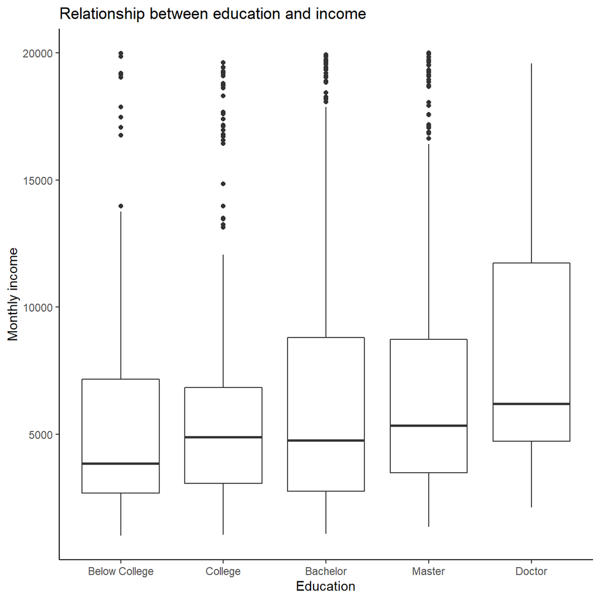

```r
level_order <- c('Below College', 'College', 'Bachelor', 'Master', 'Doctor')

education_income <- hr_cleaned %>%
  group_by(education)
ggplot(data = education_income, mapping = aes(x = factor(education, level = level_order), y = monthly_income)) + geom_boxplot() + labs(title = "Relationship between education and income", x = "Education", y = "Monthly income") +
  theme_classic() + NULL
```

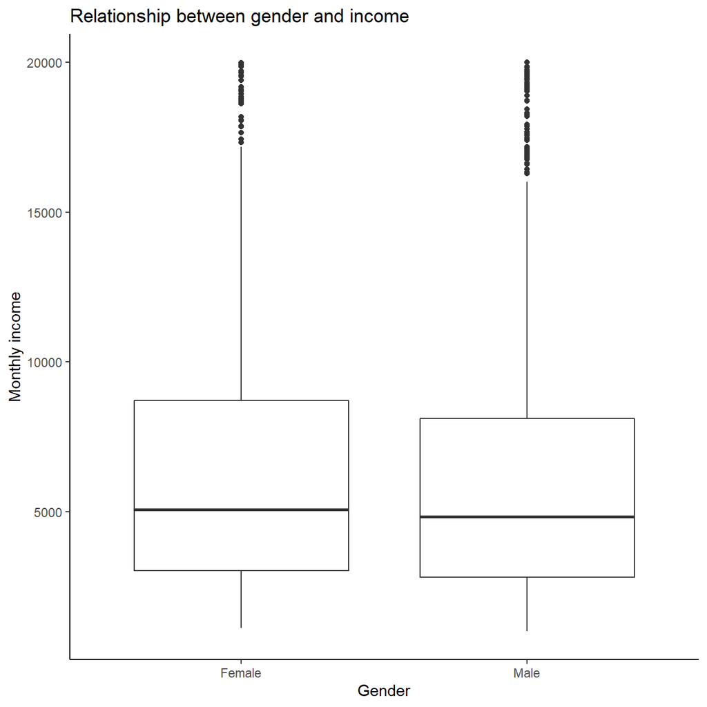

```r
gender_income <- hr_cleaned %>%
  group_by(gender)
ggplot(data = gender_income, mapping = aes(x = gender, y = monthly_income)) + geom_boxplot() + labs(title = "Relationship between gender and income", x = "Gender", y = "Monthly income") +
  theme_classic() + NULL
```

The first graph shows that a correlation between education and income exists - higher education leads to a higher salary. However, there are probably other important factors like job role that influence the monthly income as well.

Looking at the gender/ monthly income graph there is an indication that women earn more money on average, however, the difference does not seem to be significant. In contrast, the male chart shows more outlays at the top. This might reflect a top management dominated by male employees.

## 4.5 Income vs. job role

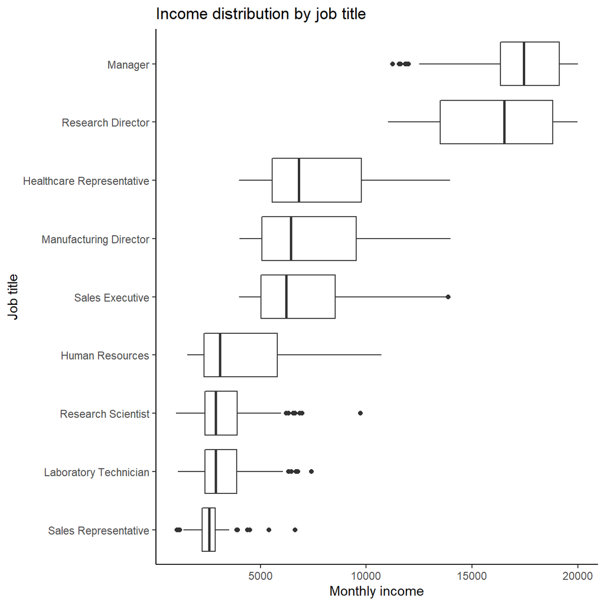

```r
ggplot(data = hr_cleaned, mapping = aes(x = reorder(factor(job_role), monthly_income), y = monthly_income)) + geom_boxplot() + labs(title = "Income distribution by job title", x = "Job title", y = "Monthly income") + coord_flip() + theme_classic() + NULL
```

## 4.6 Median income by education level

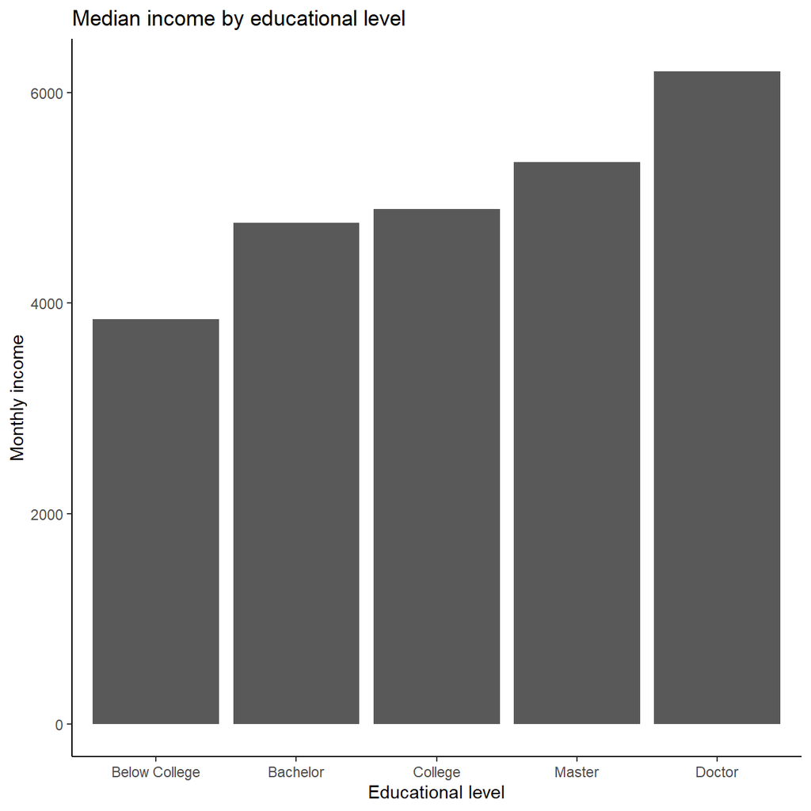

```r
income_bar_education <- hr_cleaned %>%
  group_by(education) %>%
  summarise(median_income=median(monthly_income, na.rm=TRUE))
  ggplot(data = income_bar_education, mapping = aes(x = reorder(factor(education), median_income), y = median_income)) +geom_col() + labs(title = "Median income by educational level", x = "Educational level", y = "Monthly income") +
  theme_classic()
```

Looking at the graph education does influence monthly income.

## 4.7 Distribution of income by educational level

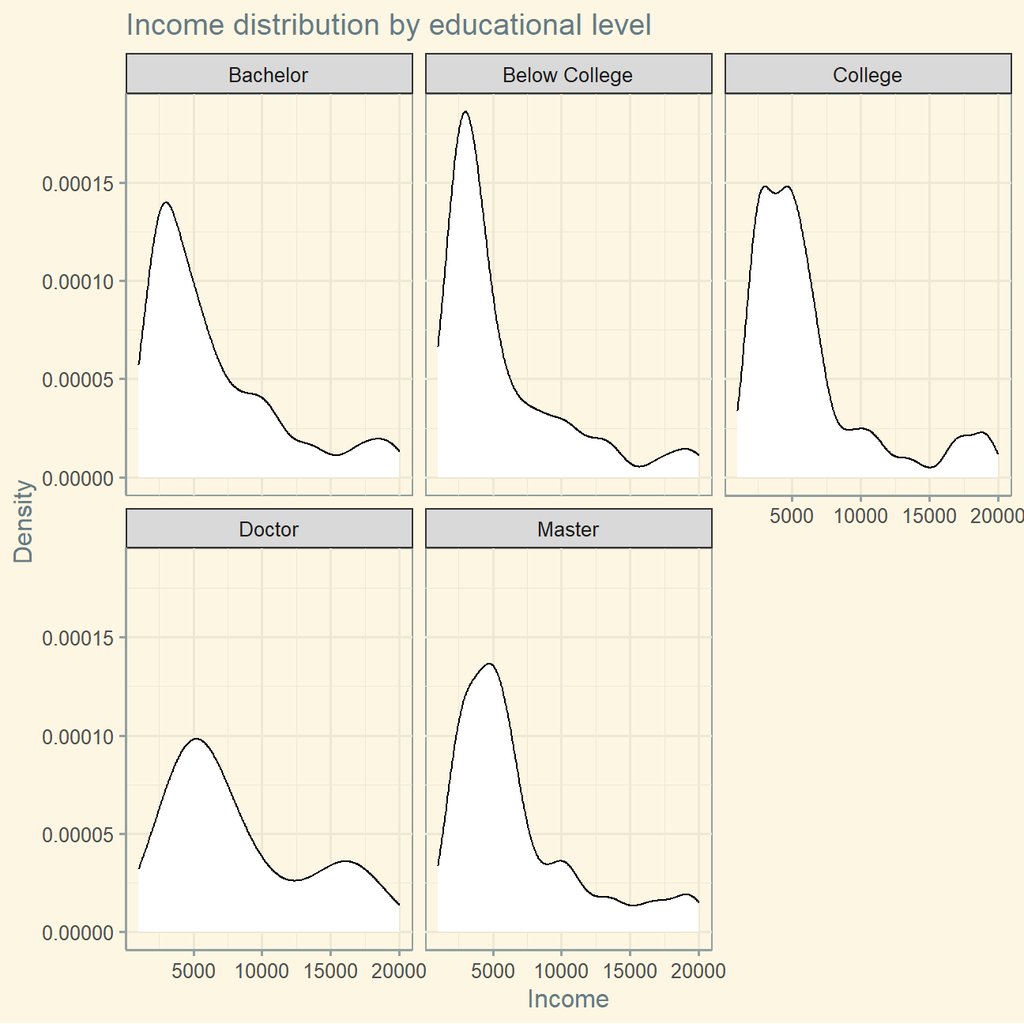

```r
ggplot(data = hr_cleaned, mapping = aes(x = monthly_income)) + geom_density(fill = "white", color = "black") + facet_wrap(~ education) +  labs(title = "Income distribution by educational level", x = "Income", y = "Density") + theme_solarized() + NULL
```

It applies for all educational levels that the highest salaries are given to a few people. Considering the hierarchical organizational structure of companies this distribution should be common across different industries.

## 4.8 Income vs. age by job role

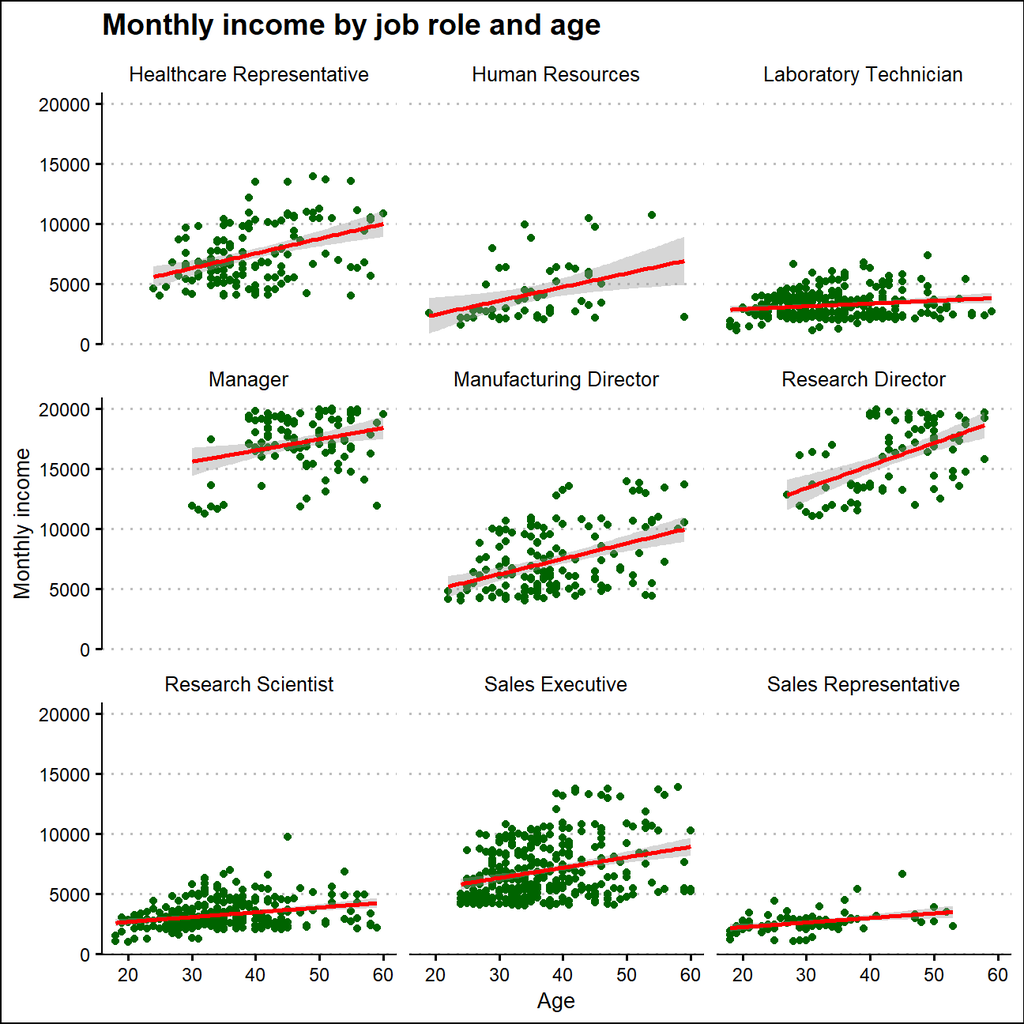

```r
ggplot(data = hr_cleaned, mapping = aes(x = age, y = monthly_income)) + geom_point(show.legend = F, color = "darkgreen") + geom_smooth(method=lm, color = "red") + facet_wrap(~ job_role) + labs(title = "Monthly income by job role and age", x = "Age", y = "Monthly income") + theme_clean() + NULL
```

While some job roles like Sales Representative or Laboratory Technician show a rather flat monthly income development, e.g. managers receive a significant higher salary with increasing age. This unequal treatment of employees might lead to ill feelings between different job role employees.

# 5 Challenge 1: Analysing the relationship between gun ownership and homicide/suicide

```r
knitr::include_graphics(here::here("images", "figure3.jpeg"), error = FALSE)
```

[output not shown]

## 5.1 Replicating the chart

```r
# Replicate Figure 3
population <- vroom::vroom(here::here("data","CDC_Males.csv"))

population %>%
  glimpse
```

```
## Rows: 104
## Columns: 28
## $ ST                      <chr> "AK", "AK", "AL", "AL", "AR", "AR", "AZ", "...
## $ State                   <chr> "Alaska", "Alaska", "Alabama", "Alabama", "...
## $ Population.Black        <dbl> 153664, 153664, 5376635, 5376635, 1991165, ...
## $ Population.White        <dbl> 2274605, 2274605, 14267619, 14267619, 97470...
## $ Deaths.homicide.Black   <dbl> 23, NA, 183, 1812, 667, 90, 300, 40, 3712, ...
## $ Deaths.homicide.White   <dbl> 78, 10, 124, 620, 416, 110, 586, 145, 1399,...
## $ crude.homicide.Black    <dbl> 14.97, NA, 3.40, 33.70, 33.50, 4.52, 22.06,...
## $ crude.homicide.White    <dbl> 3.43, NA, 0.87, 4.35, 4.27, 1.13, 3.46, 0.8...
## $ adjusted.homicide.Black <dbl> 12.30, NA, 3.51, 33.00, 33.39, 4.81, 20.40,...
## $ adjusted.homicide.White <dbl> 3.24, NA, 0.85, 4.47, 4.39, 1.13, 3.63, 0.9...
## $ Deaths.suicide.Black    <dbl> 23, 12, 148, 370, 118, 75, 101, 80, 492, 63...
## $ Deaths.suicide.White    <dbl> 535, 196, 1222, 3195, 2154, 1027, 4146, 197...
## $ crude.suicide.Black     <dbl> 14.97, NA, 2.75, 6.88, 5.93, 3.77, 7.43, 5....
## $ crude.suicide.White     <dbl> 23.52, 8.62, 8.56, 22.39, 22.10, 10.54, 24....
## $ adjusted.suicide.Black  <dbl> 12.77, NA, 2.84, 7.20, 6.25, 3.93, 7.51, 5....
## $ adjusted.suicide.White  <dbl> 23.47, 8.21, 8.64, 20.97, 20.98, 10.89, 21....
## $ type                    <chr> "Firearm", "Non-Firearm", "Non-Firearm", "F...
## $ crude.RD.suicide        <dbl> -8.55, NA, -5.81, -15.51, -16.17, -6.77, -1...
## $ adj.RD.suicide          <dbl> -10.70, NA, -5.80, -13.77, -14.73, -6.96, -...
## $ crude.RD.homicide       <dbl> 11.54, NA, 2.53, 29.35, 29.23, 3.39, 18.60,...
## $ adj.RD.homicide         <dbl> 9.06, NA, 2.66, 28.53, 29.00, 3.68, 16.77, ...
## $ ST.order.RD.homicide    <chr> "AK", "AK", "AL", "AL", "AR", "AR", "AZ", "...
## $ ST.order.RD.suicide     <chr> "AK", "AK", "AL", "AL", "AR", "AR", "AZ", "...
## $ gun.house.prev          <dbl> 59.8, 59.8, 52.2, 52.2, 58.8, 58.8, 32.3, 3...
## $ gun.house.prev.category <chr> "45.0%-65.5%", "45.0%-65.5%", "45.0%-65.5%"...
## $ average.pop.white       <dbl> 252734, 252734, 1585291, 1585291, 1083003, ...
## $ average.pop.black       <dbl> 17074, 17074, 597404, 597404, 221241, 22124...
## $ type.fac                <chr> "Firearm-related", "Firearm-unrelated", "Fi...
```

```r
#filtering out duplicates/NA data for gun ownership
gun_ownership <- population %>%
  filter(!is.na(gun.house.prev.category)) %>%
  select(ST, average.pop.white, gun.house.prev.category) %>%
  distinct()

#looking at the data structure
gun_ownership %>%
  glimpse
```

```
## Rows: 50
## Columns: 3
## $ ST                      <chr> "AK", "AL", "AR", "AZ", "CA", "CO", "CT", "...
## $ average.pop.white       <dbl> 252734, 1585291, 1083003, 1882345, 7703022,...
## $ gun.house.prev.category <chr> "45.0%-65.5%", "45.0%-65.5%", "45.0%-65.5%"...
```

```r
#getting the necessary murder/homicide data
white_population <- population %>%
  filter(type.fac == "Firearm-related") %>%
  select(ST, adjusted.homicide.White, adjusted.suicide.White)

#Looking at the data structure
white_population %>%
  glimpse
```

```
## Rows: 52
## Columns: 3
## $ ST                      <chr> "AK", "AL", "AR", "AZ", "CA", "CO", "CT", "...
## $ adjusted.homicide.White <dbl> 3.24, 4.47, 4.39, 3.63, 2.05, 1.75, 0.86, N...
## $ adjusted.suicide.White  <dbl> 23.47, 20.97, 20.98, 21.42, 11.63, 19.48, 6...
```

```r
#joining the tables
all_data <- white_population %>%
  inner_join(gun_ownership, by = "ST")

#looking at the combined data structure
all_data %>%
  glimpse
```

```
## Rows: 50
## Columns: 5
## $ ST                      <chr> "AK", "AL", "AR", "AZ", "CA", "CO", "CT", "...
## $ adjusted.homicide.White <dbl> 3.24, 4.47, 4.39, 3.63, 2.05, 1.75, 0.86, 1...
## $ adjusted.suicide.White  <dbl> 23.47, 20.97, 20.98, 21.42, 11.63, 19.48, 6...
## $ average.pop.white       <dbl> 252734, 1585291, 1083003, 1882345, 7703022,...
## $ gun.house.prev.category <chr> "45.0%-65.5%", "45.0%-65.5%", "45.0%-65.5%"...
```

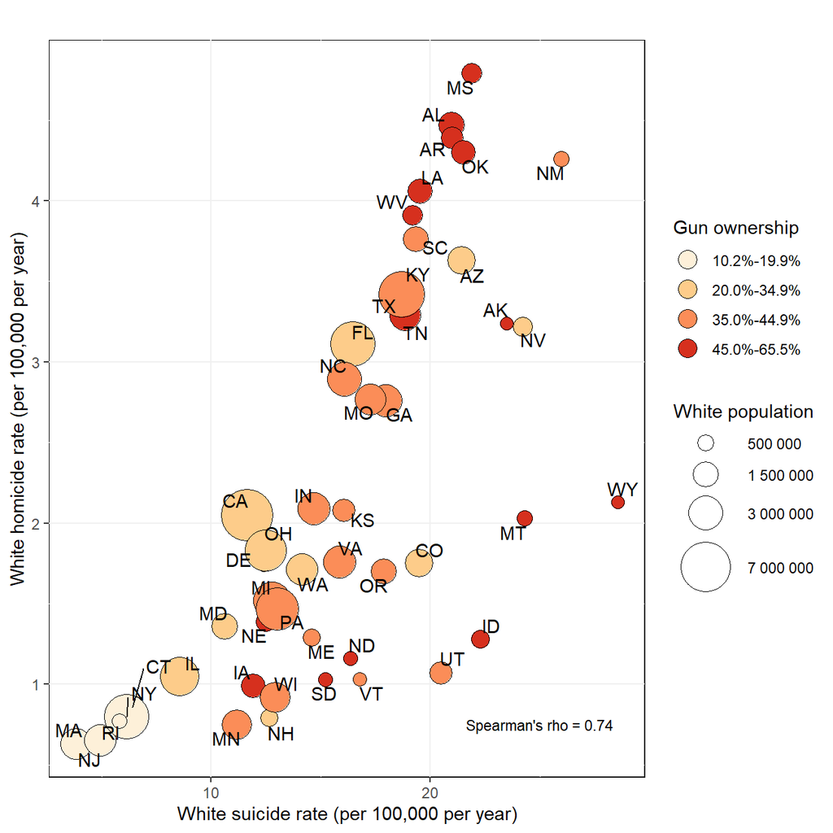

```r
#plotting the data
ggplot(all_data, aes(x = adjusted.suicide.White, y = adjusted.homicide.White, label = ST)) +
  geom_point(aes(fill = factor(gun.house.prev.category),
                 size = average.pop.white), pch = 21) +

  labs(title = "", x="White suicide rate (per 100,000 per year)",
       y="White homicide rate (per 100,000 per year)") +

  scale_fill_manual(values = c("#fdf0d9", "#fdcc8a", "#fb8d58", "#d6301e"),  name = "Gun ownership") + scale_size_continuous(name = "White population", breaks = c(500000, 1500000, 3000000, 7000000),labels = c("500 000", "1 500 000", "3 000 000", "7 000 000"), range = c(1,15),limits = c(0, 9000000)) + geom_text_repel() +

  annotate(geom="text", x=25, y=0.75, size =3, label="Spearman's rho = 0.74") + theme(panel.grid.major = element_line(colour = "#f0f0f0"),
                                                                                      panel.background = element_rect(colour = "black", size=0.5, fill = NA),legend.key = element_rect(colour = "transparent", fill = "transparent")) +
  guides(fill = guide_legend(order = 1, override.aes = list(size = 5)),
         size = guide_legend(order = 2))
```

# 6 Challenge 2: 2016 California Contributors plots

```r
knitr::include_graphics(here::here("images", "challenge2.png"), error = FALSE)
```

[output not shown]

## 6.1 Plotting total donations by Californian cities for 2016 presidential candidates

```r
# Make sure you use vroom() as it is significantly faster than read.csv()
CA_contributors_2016 <- vroom::vroom(here::here("data","CA_contributors_2016.csv"))
zip_codes <- vroom::vroom(here::here("data","zip_code_database.csv"))

CA_contributors_2016 %>%
  glimpse %>%
  skim
```

```
## Rows: 1,292,843
## Columns: 4
## $ cand_nm           <chr> "Clinton, Hillary Rodham", "Clinton, Hillary Rodh...
## $ contb_receipt_amt <dbl> 50.0, 200.0, 5.0, 48.3, 40.0, 244.3, 35.0, 100.0,...
## $ zip               <dbl> 94939, 93428, 92337, 95334, 93011, 95826, 90278, ...
## $ contb_date        <date> 2016-04-26, 2016-04-20, 2016-04-02, 2016-11-21, ...
```

Data summary

| Name | Piped data |
| --- | --- |
| Number of rows | 1292843 |
| Number of columns | 4 |
| _______________________ |  |
| Column type frequency: |  |
| character | 1 |
| Date | 1 |
| numeric | 2 |
| ________________________ |  |
| Group variables | None |

**Variable type: character**

| skim_variable | n_missing | complete_rate | min | max | empty | n_unique | whitespace |
| --- | --- | --- | --- | --- | --- | --- | --- |
| cand_nm | 0 | 1 | 9 | 25 | 0 | 25 | 0 |

**Variable type: Date**

| skim_variable | n_missing | complete_rate | min | max | median | n_unique |
| --- | --- | --- | --- | --- | --- | --- |
| contb_date | 0 | 1 | 2013-11-05 | 2016-12-31 | 2016-05-31 | 732 |

**Variable type: numeric**

| skim_variable | n_missing | complete_rate | mean | sd | p0 | p25 | p50 | p75 | p100 | hist |
| --- | --- | --- | --- | --- | --- | --- | --- | --- | --- | --- |
| contb_receipt_amt | 0 | 1 | 120 | 389 | -8300 | 15 | 27 | 94 | 10800 | ▁▁▇▁▁ |
| zip | 0 | 1 | 93127 | 1839 | 90001 | 91604 | 93422 | 94611 | 96162 | ▆▅▅▇▆ |

```r
zip_codes %>%
  glimpse %>%
  skim
```

```
## Rows: 42,522
## Columns: 16
## $ zip                  <chr> "00501", "00544", "00601", "00602", "00603", "...
## $ type                 <chr> "UNIQUE", "UNIQUE", "STANDARD", "STANDARD", "S...
## $ primary_city         <chr> "Holtsville", "Holtsville", "Adjuntas", "Aguad...
## $ acceptable_cities    <chr> NA, NA, NA, NA, "Ramey", "Ramey", NA, NA, NA, ...
## $ unacceptable_cities  <chr> "I R S Service Center", "Irs Service Center", ...
## $ state                <chr> "NY", "NY", "PR", "PR", "PR", "PR", "PR", "PR"...
## $ county               <chr> "Suffolk County", "Suffolk County", "Adjuntas"...
## $ timezone             <chr> "America/New_York", "America/New_York", "Ameri...
## $ area_codes           <dbl> 631, 631, 787939, 787, 787, NA, NA, 787939, 78...
## $ latitude             <dbl> 40.8, 40.8, 18.2, 18.4, 18.4, 18.4, 18.4, 18.2...
## $ longitude            <dbl> -73.0, -73.0, -66.7, -67.2, -67.2, -67.2, -67....
## $ world_region         <chr> NA, NA, NA, NA, NA, NA, NA, NA, NA, NA, NA, NA...
## $ country              <chr> "US", "US", "US", "US", "US", "US", "US", "US"...
## $ decommissioned       <dbl> 0, 0, 0, 0, 0, 0, 0, 0, 0, 0, 0, 0, 0, 0, 0, 0...
## $ estimated_population <dbl> 384, 0, 0, 0, 0, 0, 0, 0, 0, 0, 0, 0, 0, 0, 0,...
## $ notes                <chr> NA, NA, NA, NA, NA, NA, NA, NA, NA, "no NWS da...
```

Data summary

| Name | Piped data |
| --- | --- |
| Number of rows | 42522 |
| Number of columns | 16 |
| _______________________ |  |
| Column type frequency: |  |
| character | 11 |
| numeric | 5 |
| ________________________ |  |
| Group variables | None |

**Variable type: character**

| skim_variable | n_missing | complete_rate | min | max | empty | n_unique | whitespace |
| --- | --- | --- | --- | --- | --- | --- | --- |
| zip | 0 | 1.00 | 5 | 5 | 0 | 42522 | 0 |
| type | 0 | 1.00 | 6 | 8 | 0 | 4 | 0 |
| primary_city | 0 | 1.00 | 3 | 27 | 0 | 18758 | 0 |
| acceptable_cities | 33512 | 0.21 | 3 | 282 | 0 | 7162 | 0 |
| unacceptable_cities | 30236 | 0.29 | 2 | 2208 | 0 | 10468 | 0 |
| state | 0 | 1.00 | 2 | 2 | 0 | 62 | 0 |
| county | 850 | 0.98 | 7 | 39 | 0 | 1923 | 0 |
| timezone | 1917 | 0.95 | 12 | 28 | 0 | 26 | 0 |
| world_region | 42189 | 0.01 | 2 | 2 | 0 | 8 | 0 |
| country | 0 | 1.00 | 2 | 2 | 0 | 61 | 0 |
| notes | 41191 | 0.03 | 13 | 124 | 0 | 10 | 0 |

**Variable type: numeric**

| skim_variable | n_missing | complete_rate | mean | sd | p0 | p25 | p50 | p75 | p100 | hist |
| --- | --- | --- | --- | --- | --- | --- | --- | --- | --- | --- |
| area_codes | 1240 | 0.97 | 5.19e+24 | 1.05e+27 | 201.0 | 406.0 | 620.0 | 870.0 | 2.14e+29 | ▇▁▁▁▁ |
| latitude | 0 | 1.00 | 3.79e+01 | 7.18e+00 | -44.2 | 34.7 | 39.0 | 41.8 | 7.13e+01 | ▁▁▁▇▁ |
| longitude | 0 | 1.00 | -8.95e+01 | 1.97e+01 | -176.7 | -97.1 | -87.7 | -79.8 | 1.71e+02 | ▂▇▁▁▁ |
| decommissioned | 0 | 1.00 | 2.00e-02 | 1.20e-01 | 0.0 | 0.0 | 0.0 | 0.0 | 1.00e+00 | ▇▁▁▁▁ |
| estimated_population | 0 | 1.00 | 5.65e+03 | 9.72e+03 | 0.0 | 0.0 | 1168.0 | 6207.2 | 8.85e+04 | ▇▁▁▁▁ |

```r
library(patchwork)
library(tidytext)

#Get total donations per zip code per candidate
donations_by_zip <- CA_contributors_2016 %>%
  group_by(cand_nm, zip) %>%
  summarize(total_by_zip = sum(contb_receipt_amt))

#Filter out the unnecessary information in the zip_codes data
cali_cities <- zip_codes %>%
  filter(state == "CA") %>%
  transform(zip = as.double(zip)) %>%
  select(zip, primary_city)

#Find the donations per city for all candidates
donations_by_city <- donations_by_zip %>%
  inner_join(cali_cities, by = "zip") %>%
  group_by(cand_nm, primary_city) %>%
  summarize(total_by_city = sum(total_by_zip))

#Narrow it down to just the two presidential nominees and their top 10 cities
presidentials <- donations_by_city %>%
  filter(cand_nm == "Trump, Donald J." | cand_nm == "Clinton, Hillary Rodham") %>%
  group_by(cand_nm) %>%
  slice_max(n=10, order_by = total_by_city) %>%
  ungroup()  # mutate(cand_nm = as.factor(cand_nm), reorder_within(primary_city, total_by_city, cand_nm))

# presidentials
presidentials
```

```
## # A tibble: 20 x 3
##    cand_nm                 primary_city    total_by_city
##    <chr>                   <chr>                   <dbl>
##  1 Clinton, Hillary Rodham San Francisco       12345963.
##  2 Clinton, Hillary Rodham Los Angeles         12022399.
##  3 Clinton, Hillary Rodham Oakland              2955387.
##  4 Clinton, Hillary Rodham Palo Alto            2664346.
##  5 Clinton, Hillary Rodham Berkeley             2300980.
##  6 Clinton, Hillary Rodham Beverly Hills        2226442.
##  7 Clinton, Hillary Rodham Santa Monica         2134503.
##  8 Clinton, Hillary Rodham San Diego            2094960.
##  9 Clinton, Hillary Rodham Sacramento           1623772.
## 10 Clinton, Hillary Rodham Los Altos            1500963.
## 11 Trump, Donald J.        Los Angeles           544464.
## 12 Trump, Donald J.        San Diego             482885.
## 13 Trump, Donald J.        Newport Beach         347206.
## 14 Trump, Donald J.        Bakersfield           244419.
## 15 Trump, Donald J.        San Francisco         230712.
## 16 Trump, Donald J.        San Jose              190652.
## 17 Trump, Donald J.        Fresno                182674.
## 18 Trump, Donald J.        Rancho Santa Fe       178233.
## 19 Trump, Donald J.        Sacramento            171656.
## 20 Trump, Donald J.        Irvine                157518.
```

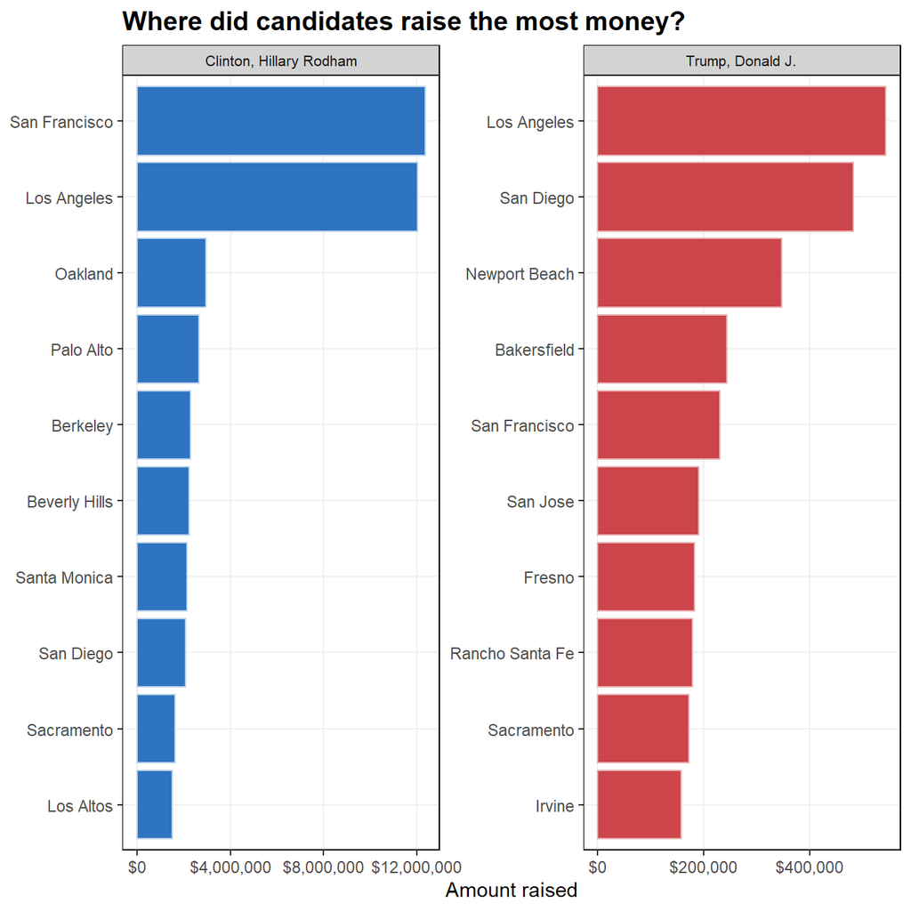

```r
pres_plot <- ggplot(presidentials, aes(x=reorder_within(primary_city, total_by_city, cand_nm), total_by_city, y = total_by_city)) +
  geom_bar(stat='identity', aes(color = as.factor(cand_nm), fill = as.factor(cand_nm)), show.legend = FALSE) +
  coord_flip() +
  labs(title = "Where did candidates raise the most money?", y = "Amount raised") +
  scale_y_continuous(labels = scales::dollar) +
  scale_x_reordered() +
  scale_fill_manual(values = c("#2e74c0", "#cb454a")) +
  scale_color_manual(values = c("#bcd3eb", "#eab2b4")) +
  ggtitle("Where did candidates raise the most money?") +
  theme(plot.title = element_text(size = 30, face = "bold")) +
  facet_wrap(~cand_nm, scales = "free") +
  theme(strip.background = element_rect(fill="lightGrey", color = "black", size = 0.5),
              strip.text = element_text(size=8),
              panel.border = element_rect(colour = "black", size=0.5, fill = NA, linetype = "solid"),
        panel.background = element_rect(fill = "white"),
        panel.grid.major = element_line(colour = "#f0f0f0"),
              plot.title = element_text(size = 8),
              axis.title.y = element_blank()) + theme(plot.title = element_text(size = 14))

pres_plot
```

# 7 Deliverables

There is a lot of explanatory text, comments, etc. You do not need these, so delete them and produce a stand-alone document that you could share with someone. Knit the edited and completed R Markdown file as an HTML document (use the “Knit” button at the top of the script editor window) and upload it to Canvas.

# 8 Details

- Who did you collaborate with: Aman Sharma, Christoph Sieker, Satyam Gorry, Kasia Gasiewska, Peter Moravec, Philippe Schrage
- Approximately how much time did you spend on this problem set: 50 hours
- What, if anything, gave you the most trouble: Challenges 1 and 2, difficult to know how to start

# 9 Rubric

Check minus (1/5): Displays minimal effort. Doesn’t complete all components. Code is poorly written and not documented. Uses the same type of plot for each graph, or doesn’t use plots appropriate for the variables being analyzed.

Check (3/5): Solid effort. Hits all the elements. No clear mistakes. Easy to follow (both the code and the output).

**Check plus (5/5): Finished all components of the assignment correctly and addressed both challenges. Code is well-documented (both self-documented and with additional comments as necessary). Used tidyverse, instead of base R. Graphs and tables are properly labelled. Analysis is clear and easy to follow, either because graphs are labeled clearly or you’ve written additional text to describe how you interpret the output.**